# Data preparation

# Summary

This section explains in detail the preparation of a database with the GBIF data for *Plantae*, the Terrestrial Ecoregions of the World, country limits, and environmental data. The main objective is to find out what plant species are present on each ecoregion.

# Data

## *Plantae* data from GBIF

Done from the website, with the DOI https://doi.org/10.15468/dl.xh5y5g, (URL https://www.gbif.org/es/occurrence/download/0061691-200613084148143).

The query had the following filtering criteria:

Basis of record: Observación, Observación humana, Muestra de material, Literatura, Espécimen preservado, Observación con máquina, and Espécimen vivo. Includes coordinates: true Geospatial issues: false Occurrence status: present Scientific name: Plantae

It results in 244830168 records from 4741 datasets downloaded in a file named *0061691-200613084148143.zip*. The size of the csv of the same name is 131GB.

## Terrestrial Ecoregions of the World (TEOW)

This dataset is stored at `data/ecoregions/wwf_terr_ecos.shp`, and generated by by Olson *et al*. (2001), is hosted at https://www.worldwildlife.org/publications/terrestrial-ecoregions-of-the-world. It is a shapefile with 867 terrestrial ecoregions classified into 14 biomes.

The key attributes of this dataset are:

- OBJECTID: unique identifier for each ecoregion.
- AREA: total area of the ecoregion.
- PERIMETER: total perimeter of the ecoregion.
- ECO_NAME: name of the ecoregion.
- BIOME: biome the ecoregion belongs to.

## Limits of the world countries

This shapefile is stored in `data/countries/countries.shp`, and contains the limits of the countries of the world. The key columns are:

- OBJECTID: unique identifier for each country
- ISO: ISO acronym of the country.
- NAME_ENGLI: country name.

# Preparing the data

## Setting up the working environment

We first install and load several R packages.

The package `sparklyr` is an `R` interface to [Apache Spark](https://spark.apache.org/). Spark is an engine for large-data processing, and allows `R` to work with files larger than the RAM memory of a computer. It does so by separating a dataset into pieces (chunks) that are written into the hard disk. Data processing in Spark is done in parallel, and each data chunk is managed independently by a *worker*. Spark datasets are named DataFrames, but they have nothing to do with the traditional data frames used by `R`. However, Spark DataFrames can easily be processed with `dplyr` through `sparklyr`. Since Spark DataFrames are stored in the hard disk, data processing operations are still relatively slow, but much faster than in a traditional database.

### Setting up Spark

The package `sparklyr` helps to install Spark easily. The version install is `3.0.0` because it is compatible with `Java 11`, installed in my computer.

During the Spark configuration it is very important to give it the location of the PostgreSQL driver (downloaded from the PostgreSQL webpage).

```r
#settting total Spark memory
# Sys.setenv("SPARK_MEM" = "20g")

#acquiring the configuration
spark.config <- sparklyr::spark_config()

#adding postgresql driver
spark.config$`sparklyr.shell.driver-class-path` <- "/home/blas/Dropbox/GITHUB/gbif_plantae/postgresql-42.2.16.jar"

#type of deployment
spark.config$`sparklyr.shell.deploy-mode` <- "client"

#memory management
spark.config$`sparklyr.shell.driver-memory` <- "28G"
# spark.config$`sparklyr.shell.executor-memory` <- '3.7G'
spark.config$spark.memory.fraction <- 0.1
spark.config$spark.dynamicAllocation.enabled <- "true"
spark.config$spark.memory.offHeap.enabled <- "true"
spark.config$spark.memory.offHeap.size <- "20G"

#establishing the connection
spark.connection <- sparklyr::spark_connect(
  master = "local",
  config = spark.config,
  version = "3.0.0"
  )
```

Before starting, it is quite advisable to read “10 things I wish someone had told me before I started using Apache SparkR”.

The spark GUI can either be opened with:

```r
sparklyr::spark_web(spark.connection)
```

or by writing `http://localhost:4040` in the web browser.

### Setting up PostgreSQL and PostGIS

From synaptic, install `postgresql-12`, `postgresql-12-postgis-3`, `postgresql-contrib`, and `pgadmin3`.

PostgreSQL has a default user named `postgres`. This user can create and access any database in the local server. By default it has no password. Here we define the password `postgres` for the user `postgres`.

`sudo -u postgres psql -c "ALTER USER postgres PASSWORD 'postgres';"`

To configure the server, from the system shell we first create the user and password. In this case I use my name and my personal password.

`sudo -u postgres createuser --interactive`

The database files will live in the folder `/var/lib/postgresql/12/main` (the actual path can be found by executing `SHOW data_directory;` in psql or Pgadmin4), where 12 is the version number of PostgreSQL installed in the system. If that folder is in a drive with not enough space to host the database, another data folder can be defined as follows.

```bash
#stopping postgresql server
sudo systemctl stop postgresql

#check that it actually worked
sudo systemctl status postgresql

#open postgresql.conf
sudo gedit /etc/postgresql/12/main/postgresql.conf
```

In the text editor, replace `data_directory = '/var/lib/postgresql/12/main'` with `data_directory = '/media/workshop/posstgresql_data/main'`, and restart the postgresql server.

```bash
sudo systemctl start postgresql
sudo systemctl status postgresql
```

Creating the project database

`sudo -u blas createdb flora_ecoregions`

Getting into the `flora_ecoregions` database:

`psql flora_ecoregions blas`

To activate the postgis extension, for the database `flora_ecoregions` execute these SQL clauses in psql (if it doesn’t work, it can be done later from the *Query tool* of Pgadmin4):

```r
CREATE EXTENSION postgis;
CREATE EXTENSION postgis_raster;
CREATE EXTENSION postgis_topology;
CREATE EXTENSION postgis_sfcgal;
SELECT PostGIS_version();
```

The last clause should yield `3.0 USE_GEOS=1 USE_PROJ=1 USE_STATS=1` if the extension is up and running.

In case you need to check the version of PostgreSQL running in your system, from psql just type `select version();`.

## Setting up Pgadmin4

Pgadmin4 is a GUI to manage PostgreSQL databases. To install it we first need to add the software repository of the PostgreSQL Global Development Group (PGDG):

```r
wget --quiet -O - https://www.postgresql.org/media/keys/ACCC4CF8.asc | sudo apt-key add -

echo "deb http://apt.postgresql.org/pub/repos/apt/ `lsb_release -cs`-pgdg main" |sudo tee  /etc/apt/sources.list.d/pgdg.list

sudo apt update

sudo apt install pgadmin4 pgadmin4-apache2
```

The install requires an email address and an admin password.

After the install, check if the service is running.

```r
systemctl status apache2
```

Firewall rules need to be set:

```r
sudo ufw allow http
sudo ufw allow https
```

To connect with the local server, create a new connection with the IP 127.0.0.1, the user `postgres` and the password `postgres`.

### Connecting R and PostgreSQL

A good reference on how to do this can be found here https://db.rstudio.com/dplyr/. The packages `dbplyr` and `RPostgreSQL` are required to establish this connection. The function `RPostgreSQL:: dbConnect()` does the job.

```r
postgresql.connection <- RPostgreSQL::dbConnect(
  drv = "PostgreSQL",
  dbname = "flora_ecoregions",
  user = "blas",
  password = rstudioapi::askForPassword("Database password"),
  port = 5432
)
```

We can list the tables available with `RPostgreSQL::dbListTables()`.

```r
RPostgreSQL::dbListTables(postgresql.connection)
```

This will be a relatively large database, and several performance improvements can be achieved to make computations more efficient. The parameters of PostgreSQL can be consulted at https://postgresqlco.nf/en/doc/param/. The current server settings are stored in `pg_settings`.

```sql
SELECT * FROM pg_settings;
```

| name | setting | unit | category | short_desc | extra_desc | context | vartype | source | min_val | max_val | enumvals | boot_val | reset_val | sourcefile | sourceline | pending_restart |
| --- | --- | --- | --- | --- | --- | --- | --- | --- | --- | --- | --- | --- | --- | --- | --- | --- |
| allow_system_table_mods | off | NA | Developer Options | Allows modifications of the structure of system tables. | NA | postmaster | bool | default | NA | NA | NA | off | off | NA | NA | FALSE |
| application_name |  | NA | Reporting and Logging / What to Log | Sets the application name to be reported in statistics and logs. | NA | user | string | default | NA | NA | NA |  |  | NA | NA | FALSE |
| archive_cleanup_command |  | NA | Write-Ahead Log / Archive Recovery | Sets the shell command that will be executed at every restart point. | NA | sighup | string | default | NA | NA | NA |  |  | NA | NA | FALSE |
| archive_command | (disabled) | NA | Write-Ahead Log / Archiving | Sets the shell command that will be called to archive a WAL file. | NA | sighup | string | default | NA | NA | NA |  |  | NA | NA | FALSE |
| archive_mode | off | NA | Write-Ahead Log / Archiving | Allows archiving of WAL files using archive_command. | NA | postmaster | enum | default | NA | NA | {always,on,off} | off | off | NA | NA | FALSE |
| archive_timeout | 0 | s | Write-Ahead Log / Archiving | Forces a switch to the next WAL file if a new file has not been started within N seconds. | NA | sighup | integer | default | 0 | 1073741823 | NA | 0 | 0 | NA | NA | FALSE |
| array_nulls | on | NA | Version and Platform Compatibility / Previous PostgreSQL Versions | Enable input of NULL elements in arrays. | When turned on, unquoted NULL in an array input value means a null value; otherwise it is taken literally. | user | bool | default | NA | NA | NA | on | on | NA | NA | FALSE |
| authentication_timeout | 60 | s | Connections and Authentication / Authentication | Sets the maximum allowed time to complete client authentication. | NA | sighup | integer | default | 1 | 600 | NA | 60 | 60 | NA | NA | FALSE |
| autovacuum | on | NA | Autovacuum | Starts the autovacuum subprocess. | NA | sighup | bool | default | NA | NA | NA | on | on | NA | NA | FALSE |
| autovacuum_analyze_scale_factor | 0.1 | NA | Autovacuum | Number of tuple inserts, updates, or deletes prior to analyze as a fraction of reltuples. | NA | sighup | real | default | 0 | 100 | NA | 0.1 | 0.1 | NA | NA | FALSE |

[output cut: 304 more lines]

The most relevant ones are described and changed below.

**shared_buffers**

The RAM memory buffers used by the server should be around 40% of the total memory of the computer for maximum performance (the default is 128MB). Changing this parameter requires restarting the database.

To find the current value:

```sql
SHOW shared_buffers;
```

| shared_buffers |
| --- |
| 13107MB |

To change it:

[output not shown]

The server needs to be restarted from the system console

```bash
sudo systemctl restart postgresql
```

Checking that the change took place.

```sql
SHOW shared_buffers;
```

**work_mem**

Is the working memory of PostgreSQL before going into swapping. This quantity is set per transaction (not globally!).

```sql
SHOW work_mem;
```

| work_mem |
| --- |
| 4MB |

To set it for a given transaction, use `SET LOCAL`. It will reset the value of `work_mem` once the transaction is done. To found what number to use first execute `EXPLAIN` (estimates cost of a query without running it) or `EXPLAIN ANALYZE` (computes cost of a query after running it) on the query until `..external merge Disk...` does not appear any longer.

```sql
EXPLAIN SELECT * FROM plantae LIMIT 100;
-- SET LOCAL work_mem = '500MB';
-- SELECT * FROM plantae LIMIT 100;
```

| QUERY PLAN |
| --- |
| Limit (cost=0.00..4.03 rows=100 width=211) |
| -> Seq Scan on plantae (cost=0.00..4932685.44 rows=122532344 width=211) |

**maintenance_work_mem**

As above, but only for maintenance tasks such as `ANALYZE`, `VACUUM`, `CREATE`, `INDEX`, and `REINDEX`. It can be set per session.

[output not shown]

To reset it to its default value.

```sql
RESET maintenance_work_mem;
```

**cpu_tuple_cost**

Estimates the cost of processing a row. It defaults to 0.01, but according to [this StackOverflow answer](https://stackoverflow.com/a/13479410), values in the range [0.03, 0.05 should provide better performance.

[output not shown]

## Data processing with Spark

### Reading the *plantae* dataset into Spark

The function `sparklyr::spark_read_csv()` can be used to read a big csv file into Spark as follows. The reading and data fragmentation process takes a while.

```r
plantae <- sparklyr::spark_read_csv(
  spark.connection,
  name = "plantae",
  path = "data/plantae/plantae.csv",
  header = TRUE,
  delimiter = "\t"
)
```

`TIP: name R data.frames with the prefix 'rdf' and SparkR DataFrames with the prefix 'sdf'.`

To check that the table is loaded into the spark session we use `dplyr::src_tbls()`.

```r
dplyr::src_tbls(spark.connection)
```

```
[1] "plantae"
```

###Removing uneeded columns and renaming others

Columns can be dropped and renamed with `dplyr::select()`.

```r
plantae <- dplyr::select(
  plantae,
  kingdom = kingdom,
  phylum = phylum,
  class = class,
  family = family,
  genus = genus,
  species = species,
  latitude = decimalLatitude,
  longitude = decimalLongitude,
  coordinate_uncertainty = coordinateUncertaintyInMeters,
  year = year,
  taxon_key = taxonKey,
  species_key = speciesKey,
  basis_of_record = basisOfRecord,
  issue = issue
  )
colnames(plantae)
```

```
 [1] "kingdom"                "phylum"
 [3] "class"                  "family"
 [5] "genus"                  "species"
 [7] "latitude"               "longitude"
 [9] "coordinate_uncertainty" "year"
[11] "taxon_key"              "species_key"
[13] "basis_of_record"        "issue"
```

###Rounding coordinates to the third digit

When rounding coordinates to the third digit, coordinates that are meters apart become the same, and therefore redundancies can be removed by eliminating duplicates.

```r
plantae <- dplyr::mutate(
  plantae,
  latitude = round(latitude, 3),
  longitude = round(longitude, 3)
)
```

###Removing duplicates

GBIF data generally has a large number of duplicates. These can be removed with `sparklyr::sdf_drop_duplicates()`, by defining a set of columns over which to look for duplicates.

###Filtering out rows with NA

The data has rows with `NA` for the `species` and `genus` column. To remove these, we use `dplyr::filter()`.

```r
plantae <- dplyr::filter(
  plantae,
  !is.na(species),
  !is.na(genus)
)
```

### Replacing NaN with 0 in the column `coordinate_uncertainty`

The column `coordinate_uncertainty` informs about the quality of the geolocation, but most records have no values, that were imported as `NaN` into the Spark DataFrame. Since `dplyr::filter()` removes data with NA, I need to give some value to those `NaN` to avoid filtering out these records.

```r
plantae <- sparklyr::na.replace(
  plantae,
  coordinate_uncertainty  = 0
  )
```

Now I can remove records with a `coordinate_uncertainty` larger than 10km.

```r
plantae <- dplyr::filter(
  plantae,
  coordinate_uncertainty <= 10000
)
```

Since dplyr + spark use what’s named *lazy evaluation*, any data processing only occurs when the data is requested. Therefore, something like

```r
head(plantae)
```

| kingdom | phylum | class | family | genus | species | latitude | longitude | coordinate_uncertainty | year | taxon_key | species_key | basis_of_record | issue |
| --- | --- | --- | --- | --- | --- | --- | --- | --- | --- | --- | --- | --- | --- |
| Plantae | Tracheophyta | Liliopsida | Orchidaceae | Aa | Aa achalensis | -32.084 | -65.101 | 0 | 1952 | 5325296 | 5325296 | PRESERVED_SPECIMEN | COORDINATE_ROUNDED |
| Plantae | Tracheophyta | Liliopsida | Orchidaceae | Aa | Aa achalensis | -31.830 | -64.759 | 0 | 2017 | 5325296 | 5325296 | HUMAN_OBSERVATION | GEODETIC_DATUM_ASSUMED_WGS84 |
| Plantae | Tracheophyta | Liliopsida | Orchidaceae | Aa | Aa achalensis | 41.689 | -72.750 | 0 | NA | 5325296 | 5325296 | HUMAN_OBSERVATION | NA |
| Plantae | Tracheophyta | Liliopsida | Orchidaceae | Aa | Aa argyrolepis | -14.684 | -69.093 | 0 | 2008 | 5325293 | 5325293 | PRESERVED_SPECIMEN | OCCURRENCE_STATUS_INFERRED_FROM_INDIVIDUAL_COUNT;GEODETIC_DATUM_ASSUMED_WGS84 |
| Plantae | Tracheophyta | Liliopsida | Orchidaceae | Aa | Aa colombiana | -17.703 | -64.718 | 0 | 2003 | 5325285 | 5325285 | PRESERVED_SPECIMEN | GEODETIC_DATUM_ASSUMED_WGS84 |
| Plantae | Tracheophyta | Liliopsida | Orchidaceae | Aa | Aa colombiana | 1.226 | -77.338 | 1356 | 1982 | 5325285 | 5325285 | PRESERVED_SPECIMEN | NA |

will start to execute the `dplyr` commands shown above.

###Saving a copy of the original data into the `flora_ecoregions` database.

The function `sparklyr::spark_write_jdbc()` can write the `plantae` table into the `flora_ecoregions` database as follows. Notice that during the configuration of Spark, shown above, the PostgreSQL driver was downloaded from the PostgreSQL website, and its location was given to the Spark configuration file. Here the driver used needs to be mentioned again (see the `driver` argument of `sparklyr::spark_write_jdbc()`). This operation takes time.

```r
sparklyr::spark_write_jdbc(
  x = plantae,
  name = "plantae",
  options = list(
    url = "jdbc:postgresql://localhost:5432/flora_ecoregions",
    user = "postgres",
    password = "postgres",#rstudioapi::askForPassword("Database password"),
    driver = "org.postgresql.Driver"
  )
)
```

To check the size of the database once the table has been written into PostgreSQL, the following SQL clause, that gives the size in MB, can be used.

```sql
select pg_database_size('flora_ecoregions')/1024/1024;
```

| ?column? |
| --- |
| 23532 |

Alternatively, the psql console can be used, as follows.

```bash
sudo -u postgres psql
\l+ flora_ecoregions
```

[output not shown]

The connection with Spark can be closed now.

```r
sparklyr::spark_disconnect(spark.connection)
```

**TIP: dropping a database**

To drop a database

```r
-- Connecting to the current user localhost's postgres instance
sudo -u postgres psql

-- Making sure the database exists
SELECT * from pg_database where datname = 'flora_ecoregions'

-- Disallow new connections
UPDATE pg_database SET datallowconn = false WHERE datname = 'flora_ecoregions';
ALTER DATABASE flora_ecoregions CONNECTION LIMIT 1;

-- Terminate existing connections
SELECT pg_terminate_backend(pid) FROM pg_stat_activity WHERE datname = 'flora_ecoregions';

-- Drop database
DROP DATABASE flora_ecoregions
```

## Preparing the plantae table

The table needs to have a unique identifier for each row, and an index in such column

```sql
-- adding id column and creating index
ALTER TABLE plantae ADD COLUMN id bigserial PRIMARY KEY;
CREATE INDEX plantae_id_index ON plantae (id);
```

### geom column from latitude and longitude

```sql
-- adding geometry column and geom field
SELECT AddGeometryColumn ('plantae','geom',4326,'POINT',2);
UPDATE plantae SET geom = ST_SetSRID(ST_MakePoint(longitude, latitude), 4326);

-- generating spatial index
CREATE INDEX plantae_geom_index ON plantae USING GIST (geom);

-- clustering the data in the hard disk by the index (performance improvement)
CLUSTER plantae USING plantae_geom_index;
```

## Preparing table of unique species

In this section I prepare a table with the unique species found in `plantae`. The objective of this table is to store data about the taxonomy, rarity, and traits of the species used in the analysis.

```sql
-- generating table with unique species
CREATE TABLE species AS
FROM plantae
SELECT
DISTINCT
kingdom,
phylum,
class,
family,
genus,
species
ORDER BY
phylum,
class,
family,
genus,
species;

-- adding ID
ALTER TABLE species ADD COLUMN species_id bigserial PRIMARY KEY;
CREATE INDEX species_id_index ON species (species_id);

-- add column to store number of spatial records
ALTER TABLE species ADD COLUMN spatial_records integer;

-- counting spatial records of each species in plantae
WITH sq AS (
SELECT
plantae.species,
COUNT(*) as spatial_records
FROM plantae
GROUP BY species
)
UPDATE species
SET spatial_records = sq.spatial_records
FROM sq
WHERE species.species = sq.species;

-- add column to store geographic features
SELECT AddGeometryColumn ('species','geom',4326,'MULTIPOINT',2);

-- gathering the points of each species into a geom
WITH sq AS (
SELECT
ST_Collect(plantae.geom) as geom,
species
FROM plantae
GROUP BY species
)
UPDATE species
SET geom = sq.geom
FROM sq
WHERE species.species = sq.species;

-- spatial index on the geom column
CREATE INDEX species_geom_index ON species USING GIST (geom);

-- clustering the data in the hard disk by the index (performance improvement)
CLUSTER species USING species_geom_index;`
```

## Working with ecoregions

Now, `ecoregions.sql` must be executed in the PostgreSQL server.

```r
RPostgreSQL::dbSendQuery(
  conn = postgresql.connection,
  statement = readr::read_file('/home/blas/Dropbox/RESEARCH/DATA/Global_bio_ecoregions_Dinerstein_2017/ecoregions2017.sql')
)
```

We list the tables again to check that one named `ecoregions` exists.

```r
RPostgreSQL::dbListTables(postgresql.connection)
```

We can delete the columns directly in the database, and rename several other columns.

```sql
-- deleting columns
ALTER TABLE ecoregions
DROP COLUMN gid,
DROP COLUMN objectid,
DROP COLUMN biome_num,
DROP COLUMN eco_biome_,
DROP COLUMN nnh,
DROP COLUMN eco_id,
DROP COLUMN color,
DROP COLUMN color_bio,
DROP COLUMN color_nnh,
DROP COLUMN license;

-- renaming columns
ALTER TABLE ecoregions RENAME COLUMN eco_name TO ecoregion;
ALTER TABLE ecoregions RENAME COLUMN biome_name TO biome;
ALTER TABLE ecoregions RENAME COLUMN shape_leng TO perimeter;
ALTER TABLE ecoregions RENAME COLUMN shape_area TO area;
ALTER TABLE ecoregions RENAME COLUMN nnh_name TO conservation_assessment;
```

As the table `plantae`, `ecoregions` needs a unique ID as primary key, an index on this column, and an index in the geom column.

```r
ALTER TABLE ecoregions ADD COLUMN id serial PRIMARY KEY;
CREATE INDEX ecoregions_id_index ON ecoregions (id);

CREATE INDEX ecoregions_geom_index ON ecoregions USING GIST (geom);
```

To compute update the `area` field (because I am not sure how it was computed in the first place) in square kilometers:

```sql
UPDATE ecoregions
SET area = ST_Area(geom::geography) / 1000000;
```

I also reduce the complexity of the polygons to speed-up spatial queries with `ST_Simplify`. This function does not work well with latitude and longitude data, hence I transform to src 32701 (UTM Zone 1, but others would work as well) and then back to 4326 (latlong WGS84) with `ST_Transform`.

```sql
ALTER TABLE ecoregions
ADD COLUMN geom_simple geometry;

UPDATE ecoregions
SET geom_simple = ST_Transform(ST_Simplify(ST_Transform(geom, 32701), 10000), 4326);

CREATE INDEX ecoregions_geom_simple_index ON ecoregions USING GIST (geom_simple);
```

## Joining ecoregions and presence records

First, the unique coordinates in `plantae` need to be extracted into a new table.

```sql
-- Getting distinct coordinates from plantae to avoid querying on duplicated coordinates
CREATE TABLE plantae_unique_coordinates AS
SELECT DISTINCT ON (ST_AsBinary(geom))
geom, latitude, longitude FROM plantae;

-- Spatial index
CREATE INDEX plantae_unique_coordinates_geom_index ON plantae_unique_coordinates USING GIST (geom);

-- Clustering by gist index
CLUSTER plantae_unique_coordinates USING plantae_unique_coordinates_geom_index;
```

Second, the spatial join between `plantae_unique_coordinates` and `ecoregions`.

```sql
CREATE TABLE temp_spatial_join AS
SELECT
plantae_unique_coordinates.latitude,
plantae_unique_coordinates.longitude,
ecoregions.id,
ecoregions.ecoregion,
ecoregions.realm,
ecoregions.biome
FROM ecoregions
JOIN plantae_unique_coordinates
ON ST_Intersects(ecoregions.geom_simple, plantae_unique_coordinates.geom);
```

```sql
CREATE TABLE plantae_ecoregions AS
SELECT
plantae.id,
plantae.latitude,
plantae.longitude,
plantae.geom,
plantae.phylum,
plantae.class,
plantae.family,
plantae.genus,
plantae.species,
temp_spatial_join.ecoregion,
temp_spatial_join.realm,
temp_spatial_join.biome
FROM plantae, temp_spatial_join
WHERE (plantae.latitude = temp_spatial_join.latitude AND
    plantae.longitude = temp_spatial_join.longitude);

CREATE INDEX plantae_ecoregions_id_index ON plantae_ecoregions (id);
CREATE INDEX plantae_ecoregions_geom_index ON plantae_ecoregions USING GIST (geom);
CLUSTER plantae_ecoregions USING plantae_ecoregions_geom_index;
```

**TIP: cancelling a long query**

1. Find the `pid` of the query. This can be achieved by looking at `top` or `htop` for the user `postgres`:

```bash
htop -u postgres
```

Or by executing the SQL clause

```sql
SELECT
  pid,
  now() - pg_stat_activity.query_start AS duration,
  query,
  state
FROM pg_stat_activity
WHERE (now() - pg_stat_activity.query_start) > interval '5 minutes';
```

which finds the running queries, and informs about the time they have been running, and the SQL clause that launched it. To cancel the query…

```sql
SELECT pg_cancel_backend(xxxx);
```

…where xxxx is the `pid` number of the query.

If a query gets stuck

```sql
SELECT pg_terminate_backend(xxxx);
```

It is convenient to stop and restart the PostgreSQL server.

```bash
sudo systemctl restart postgresql
sudo systemctl status postgresql
```

###Species list per ecoregion

Unique taxonomic units per ecoregion

```sql
-- for all plant species
CREATE TABLE ecoregions_species AS
SELECT
DISTINCT (species),
ecoregion
FROM plantae_ecoregions;

CREATE TABLE ecoregions_species_taxonomy AS
SELECT
DISTINCT (species),
genus,
family,
class,
phylum,
ecoregion
FROM plantae_ecoregions;

DELETE FROM ecoregions_species_taxonomy
WHERE NOT (ecoregions_species_taxonomy is NOT NULL);

CREATE TABLE ecoregions_genera AS
SELECT
DISTINCT (genus),
ecoregion
FROM plantae_ecoregions;

CREATE TABLE ecoregions_families AS
SELECT
DISTINCT (family),
ecoregion
FROM plantae_ecoregions;

CREATE TABLE ecoregions_classes AS
SELECT
DISTINCT (class),
ecoregion
FROM plantae_ecoregions;

CREATE TABLE ecoregions_phyla AS
SELECT
DISTINCT (phylum),
ecoregion
FROM plantae_ecoregions;

-- for vascular plants only
CREATE TABLE ecoregions_species_vascular AS
SELECT
DISTINCT (species),
ecoregion
FROM plantae_ecoregions
WHERE phylum = 'Tracheophyta';

CREATE TABLE ecoregions_genera_vascular AS
SELECT
DISTINCT (genus),
ecoregion
FROM plantae_ecoregions
WHERE phylum = 'Tracheophyta';

CREATE TABLE ecoregions_families_vascular AS
SELECT
DISTINCT (family),
ecoregion
FROM plantae_ecoregions
WHERE phylum = 'Tracheophyta';

CREATE TABLE ecoregions_classes_vascular AS
SELECT
DISTINCT (class),
ecoregion
FROM plantae_ecoregions
WHERE phylum = 'Tracheophyta';
```

For each ecoregion I need to count the total number of spatial records available (repeated records over time were removed in Spark), the number of records available for each species, and the list of species present in the ecoregion. Such data is available in the table `plantae_ecoregions`.

To get the number of records available per ecoregion, I need to sum records in `plantae_ecoregions` grouping by the column `ecoregion`, and then, I need to join the output with the table `ecoregions`.

```sql
-- creating the column to store results
ALTER TABLE ecoregions
ADD COLUMN count_records bigint;

-- computing records per ecoregion
WITH sq AS (
  SELECT
    plantae_ecoregions.ecoregion,
    COUNT(*) as count_records
  FROM plantae_ecoregions
GROUP BY plantae_ecoregions.ecoregion
)
UPDATE ecoregions
SET count_records = sq.count_records
FROM sq
WHERE ecoregions.ecoregion = sq.ecoregion;
```

To attach the number of taxa per ecoregion:

```sql
-- species
ALTER TABLE ecoregions
ADD COLUMN count_species bigint;

WITH sq AS (
SELECT
COUNT(*) AS count_species,
ecoregion
FROM ecoregions_species
GROUP BY ecoregion
)
UPDATE ecoregions
SET count_species = sq.count_species
FROM sq
WHERE ecoregions.ecoregion = sq.ecoregion;


-- genera
ALTER TABLE ecoregions
ADD COLUMN count_genera bigint;

WITH sq AS (
SELECT
COUNT(*) AS count_genera,
ecoregion
FROM ecoregions_genera
GROUP BY ecoregion
)
UPDATE ecoregions
SET count_genera = sq.count_genera
FROM sq
WHERE ecoregions.ecoregion = sq.ecoregion;


--families
ALTER TABLE ecoregions
ADD COLUMN count_families bigint;

WITH sq AS (
SELECT
COUNT(*) AS count_families,
ecoregion
FROM ecoregions_families
GROUP BY ecoregion
)
UPDATE ecoregions
SET count_families = sq.count_families
FROM sq
WHERE ecoregions.ecoregion = sq.ecoregion;


-- classes
ALTER TABLE ecoregions
ADD COLUMN count_classes bigint;

WITH sq AS (
SELECT
COUNT(*) AS count_classes,
ecoregion
FROM ecoregions_classes
GROUP BY ecoregion
)
UPDATE ecoregions
SET count_classes = sq.count_classes
FROM sq
WHERE ecoregions.ecoregion = sq.ecoregion;


-- phyla
ALTER TABLE ecoregions
ADD COLUMN count_phyla bigint;

WITH sq AS (
SELECT
COUNT(*) AS count_phyla,
ecoregion
FROM ecoregions_phyla
GROUP BY ecoregion
)
UPDATE ecoregions
SET count_phyla = sq.count_phyla
FROM sq
WHERE ecoregions.ecoregion = sq.ecoregion;

-- species of vascular plants
ALTER TABLE ecoregions
ADD COLUMN count_species_vascular bigint;

WITH sq AS (
SELECT
COUNT(*) AS count_species_tracheophyta,
ecoregion
FROM ecoregions_species_vascular
GROUP BY ecoregion
)
UPDATE ecoregions
SET count_species_vascular = count_species_vascular
FROM sq
WHERE ecoregions.ecoregion = sq.ecoregion;


-- genera
ALTER TABLE ecoregions
ADD COLUMN count_genera_vascular bigint;

WITH sq AS (
SELECT
COUNT(*) AS count_genera_vascular,
ecoregion
FROM ecoregions_genera_vascular
GROUP BY ecoregion
)
UPDATE ecoregions
SET count_genera_vascular = sq.count_genera_vascular
FROM sq
WHERE ecoregions.ecoregion = sq.ecoregion;


-- ecoregions
ALTER TABLE ecoregions
ADD COLUMN count_families_vascular bigint;

WITH sq AS (
SELECT
COUNT(*) AS count_families_vascular,
ecoregion
FROM ecoregions_families
GROUP BY ecoregion
)
UPDATE ecoregions
SET count_families_vascular = sq.count_families_vascular
FROM sq
WHERE ecoregions.ecoregion = sq.ecoregion;


-- classes
ALTER TABLE ecoregions
ADD COLUMN count_classes_vascular bigint;

WITH sq AS (
SELECT
COUNT(*) AS count_classes_vascular,
ecoregion
FROM ecoregions_classes
GROUP BY ecoregion
)
UPDATE ecoregions
SET count_classes_vascular = sq.count_classes_vascular
FROM sq
WHERE ecoregions.ecoregion = sq.ecoregion;
```

###Adding region names

```bash
shp2pgsql -s 4326 -I /home/blas/Dropbox/RESEARCH/DATA/Global_human_country_limits_shp/world_limits_clean.shp world_limits > /home/blas/Dropbox/RESEARCH/DATA/Global_human_country_limits_shp/world_limits_clean.sql
```

```r
RPostgreSQL::dbSendQuery(
  conn = postgresql.connection,
  statement = readr::read_file('/home/blas/Dropbox/RESEARCH/DATA/Global_human_country_limits_shp/world_limits_clean.sql')
)
```

```
<PostgreSQLResult>
```

Spatial index on the `geom` column

```sql
CREATE INDEX world_limits_geom_index ON world_limits USING GIST (geom);
```

Dissolving by column `unregion2`.

```sql
-- replacing Europe and Asia with Eurasia
UPDATE world_limits
SET unregion2 = 'Eurasia'
WHERE unregion2 = 'Asia' OR unregion2 = 'Europe';

-- dissolving continents
CREATE TABLE continents AS
SELECT ST_Union(geom) AS geom,
      unregion2 AS continent
FROM world_limits
GROUP BY unregion2;

-- removing a null record (Caspian sea)
DELETE FROM continents
WHERE continent IS null;
```

Transferring continent attributes to the `ecoregions` table.

```sql
-- adding continent table
ALTER TABLE ecoregions
ADD COLUMN continent varchar;
```

```sql
-- populating the column
UPDATE ecoregions
SET continent = continents.continent
FROM continents
WHERE ST_Within(ST_PointOnSurface(ecoregions.geom_simple), continents.geom);
```

###Computing environmental stats for each ecoregion

0.95 to 1 = hyperarid 0.80 to 0.95 = arid 0.50 to 0.80= semiarid 0.44 to 0.50 = dry subhumid 0.35 to 0.44 = humid -9 to 0.35 = hyperhumid

I loaded the `Ecoregions2017.shp` file onto GRASS GIS and computed areal stats for the aridity map on each ecoregion.

```bash
#importing the ecoregions vectorial file as ecoregions_aridity
v.in.ogr -w input=/home/blas/Dropbox/RESEARCH/DATA/Global_bio_ecoregions_Dinerstein_2017/Ecoregions2017_fixed_geometry.shp layer=Ecoregions2017_fixed_geometry output=ecoregions

#copy map with another
g.copy vector=ecoregions@PERMANENT,ecoregions_climate

#computing area stats
v.rast.stats map=ecoregions_climate@PERMANENT raster=climate_aridity_index,climate_PET_seasonality,climate_annual_PET,climate_bio1,climate_bio12,climate_bio4,climate_bio15,climate_bio5,climate_growing_degree_days_5,climate_velocity_LGM,human_footprint,landcover_bare_soil_percent,landcover_herbaceous_percent,landcover_trees_percent,ndvi_min,ndvi_max column_prefix=climate_aridity_index,climate_PET_seasonality,climate_annual_PET,climate_bio1,climate_bio12,climate_bio4,climate_bio15,climate_bio5,climate_growing_degree_days_5,climate_velocity_LGM,human_footprint,landcover_bare_soil_percent,landcover_herbaceous_percent,landcover_trees_percent,ndvi_min,ndvi_max method=minimum,maximum,average

#sending data back to the database flora_ecoregions
v.out.postgis input=ecoregions_climate@PERMANENT output=PG:dbname=flora_ecoregions output_layer=ecoregions_climate options='GEOMETRY_NAME=geom'

#computing population sum
g.copy vector=ecoregions@PERMANENT,ecoregions_population
v.rast.stats map=ecoregions_population@PERMANENT raster=human_population column_prefix=human_population method=sum
v.out.postgis input=ecoregions_population@PERMANENT output=PG:dbname=flora_ecoregions output_layer=ecoregions_population options='GEOMETRY_NAME=geom'
```

Now that the table `ecoregions_climate` is in the database, I join it with `ecoregions`.

```sql
-- adding climate columns to ecoregions
ALTER TABLE ecoregions
ADD COLUMN climate_aridity_index_minimum numeric;

ALTER TABLE ecoregions
ADD COLUMN climate_aridity_index_maximum numeric;

ALTER TABLE ecoregions
ADD COLUMN climate_aridity_index_average numeric;

ALTER TABLE ecoregions
ADD COLUMN climate_pet_seasonality_minimum numeric;

ALTER TABLE ecoregions
ADD COLUMN climate_pet_seasonality_maximum numeric;

ALTER TABLE ecoregions
ADD COLUMN climate_pet_seasonality_average numeric;

ALTER TABLE ecoregions
ADD COLUMN climate_annual_pet_minimum numeric;

ALTER TABLE ecoregions
ADD COLUMN climate_annual_pet_maximum numeric;

ALTER TABLE ecoregions
ADD COLUMN climate_annual_pet_average numeric;

ALTER TABLE ecoregions
ADD COLUMN climate_bio1_minimum numeric;

ALTER TABLE ecoregions
ADD COLUMN climate_bio1_maximum numeric;

ALTER TABLE ecoregions
ADD COLUMN climate_bio1_average numeric;

ALTER TABLE ecoregions
ADD COLUMN climate_bio12_minimum numeric;

ALTER TABLE ecoregions
ADD COLUMN climate_bio12_maximum numeric;

ALTER TABLE ecoregions
ADD COLUMN climate_bio12_average numeric;

ALTER TABLE ecoregions
ADD COLUMN climate_bio4_minimum numeric;

ALTER TABLE ecoregions
ADD COLUMN climate_bio4_maximum numeric;

ALTER TABLE ecoregions
ADD COLUMN climate_bio4_average numeric;

ALTER TABLE ecoregions
ADD COLUMN climate_bio15_minimum numeric;

ALTER TABLE ecoregions
ADD COLUMN climate_bio15_maximum numeric;

ALTER TABLE ecoregions
ADD COLUMN climate_bio15_average numeric;

ALTER TABLE ecoregions
ADD COLUMN climate_bio5_minimum numeric;

ALTER TABLE ecoregions
ADD COLUMN climate_bio5_maximum numeric;

ALTER TABLE ecoregions
ADD COLUMN climate_bio5_average numeric;

ALTER TABLE ecoregions
ADD COLUMN climate_growing_degree_days_5_minimum numeric;

ALTER TABLE ecoregions
ADD COLUMN climate_growing_degree_days_5_maximum numeric;

ALTER TABLE ecoregions
ADD COLUMN climate_growing_degree_days_5_average numeric;

ALTER TABLE ecoregions
ADD COLUMN climate_velocity_lgm_minimum numeric;

ALTER TABLE ecoregions
ADD COLUMN climate_velocity_lgm_maximum numeric;

ALTER TABLE ecoregions
ADD COLUMN climate_velocity_lgm_average numeric;

ALTER TABLE ecoregions
ADD COLUMN human_footprint_minimum numeric;

ALTER TABLE ecoregions
ADD COLUMN human_footprint_maximum numeric;

ALTER TABLE ecoregions
ADD COLUMN human_footprint_average numeric;

ALTER TABLE ecoregions
ADD COLUMN landcover_bare_soil_percent_minimum numeric;

ALTER TABLE ecoregions
ADD COLUMN landcover_bare_soil_percent_maximum numeric;

ALTER TABLE ecoregions
ADD COLUMN landcover_bare_soil_percent_average numeric;

ALTER TABLE ecoregions
ADD COLUMN landcover_herbaceous_percent_minimum numeric;

ALTER TABLE ecoregions
ADD COLUMN landcover_herbaceous_percent_maximum numeric;

ALTER TABLE ecoregions
ADD COLUMN landcover_herbaceous_percent_average numeric;

ALTER TABLE ecoregions
ADD COLUMN landcover_trees_percent_minimum numeric;

ALTER TABLE ecoregions
ADD COLUMN landcover_trees_percent_maximum numeric;

ALTER TABLE ecoregions
ADD COLUMN landcover_trees_percent_average numeric;

ALTER TABLE ecoregions
ADD COLUMN ndvi_min_minimum numeric;

ALTER TABLE ecoregions
ADD COLUMN ndvi_min_maximum numeric;

ALTER TABLE ecoregions
ADD COLUMN ndvi_min_average numeric;

ALTER TABLE ecoregions
ADD COLUMN ndvi_max_minimum numeric;

ALTER TABLE ecoregions
ADD COLUMN ndvi_max_maximum numeric;

ALTER TABLE ecoregions
ADD COLUMN ndvi_max_average numeric;



-- populating aridity columns from ecoregions_aridity
UPDATE ecoregions
   SET climate_aridity_index_minimum = ecoregions_climate.climate_aridity_index_minimum,
       climate_aridity_index_maximum = ecoregions_climate.climate_aridity_index_maximum,
       climate_aridity_index_average = ecoregions_climate.climate_aridity_index_average,
       climate_pet_seasonality_minimum = ecoregions_climate."climate_PET_seasonality_minimum",
       climate_pet_seasonality_maximum = ecoregions_climate."climate_PET_seasonality_maximum",
       climate_pet_seasonality_average = ecoregions_climate."climate_PET_seasonality_average",
       climate_annual_pet_minimum = ecoregions_climate."climate_annual_PET_minimum",
       climate_annual_pet_maximum = ecoregions_climate."climate_annual_PET_maximum",
       climate_annual_pet_average = ecoregions_climate."climate_annual_PET_average",
       climate_bio1_minimum = ecoregions_climate.climate_bio1_minimum,
       climate_bio1_maximum = ecoregions_climate.climate_bio1_maximum,
       climate_bio1_average = ecoregions_climate.climate_bio1_average,
       climate_bio12_minimum = ecoregions_climate.climate_bio12_minimum,
       climate_bio12_maximum = ecoregions_climate.climate_bio12_maximum,
       climate_bio12_average = ecoregions_climate.climate_bio12_average,
       climate_bio4_minimum = ecoregions_climate.climate_bio4_minimum,
       climate_bio4_maximum = ecoregions_climate.climate_bio4_maximum,
       climate_bio4_average = ecoregions_climate.climate_bio4_average,
       climate_bio15_minimum = ecoregions_climate.climate_bio15_minimum,
       climate_bio15_maximum = ecoregions_climate.climate_bio15_maximum,
       climate_bio15_average = ecoregions_climate.climate_bio15_average,
       climate_bio5_minimum = ecoregions_climate.climate_bio5_minimum,
       climate_bio5_maximum = ecoregions_climate.climate_bio5_maximum,
       climate_bio5_average = ecoregions_climate.climate_bio5_average,
       climate_growing_degree_days_5_minimum = ecoregions_climate.climate_growing_degree_days_5_minimum,
       climate_growing_degree_days_5_maximum = ecoregions_climate.climate_growing_degree_days_5_maximum,
       climate_growing_degree_days_5_average = ecoregions_climate.climate_growing_degree_days_5_average,
       climate_velocity_lgm_minimum = ecoregions_climate."climate_velocity_LGM_minimum",
       climate_velocity_lgm_maximum = ecoregions_climate."climate_velocity_LGM_maximum",
       climate_velocity_lgm_average = ecoregions_climate."climate_velocity_LGM_average",
       human_footprint_minimum = ecoregions_climate.human_footprint_minimum,
       human_footprint_maximum = ecoregions_climate.human_footprint_maximum,
       human_footprint_average = ecoregions_climate.human_footprint_average,
       landcover_bare_soil_percent_minimum = ecoregions_climate.landcover_bare_soil_percent_minimum,
       landcover_bare_soil_percent_maximum = ecoregions_climate.landcover_bare_soil_percent_maximum,
       landcover_bare_soil_percent_average = ecoregions_climate.landcover_bare_soil_percent_average,
       landcover_herbaceous_percent_minimum = ecoregions_climate.landcover_herbaceous_percent_minimum,
       landcover_herbaceous_percent_maximum = ecoregions_climate.landcover_herbaceous_percent_maximum,
       landcover_herbaceous_percent_average = ecoregions_climate.landcover_herbaceous_percent_average,
       landcover_trees_percent_minimum = ecoregions_climate.landcover_trees_percent_minimum,
       landcover_trees_percent_maximum = ecoregions_climate.landcover_trees_percent_maximum,
       landcover_trees_percent_average = ecoregions_climate.landcover_trees_percent_average,
       ndvi_min_minimum = ecoregions_climate.ndvi_min_minimum,
       ndvi_min_maximum = ecoregions_climate.ndvi_min_maximum,
       ndvi_min_average = ecoregions_climate.ndvi_min_average,
       ndvi_max_minimum = ecoregions_climate.ndvi_max_minimum,
       ndvi_max_maximum = ecoregions_climate.ndvi_max_maximum,
       ndvi_max_average = ecoregions_climate.ndvi_max_average
FROM ecoregions_climate
WHERE ecoregions.ecoregion = ecoregions_climate.eco_name;

-- adding and updating human_population and human population density columns
ALTER TABLE ecoregions
ADD COLUMN human_population numeric;

UPDATE ecoregions
   SET human_population = human_population_sum
   FROM ecoregions_population
   WHERE ecoregions.ecoregion = ecoregions_population.eco_name;

ALTER TABLE ecoregions
ADD COLUMN human_population_density numeric;

UPDATE ecoregions
   SET human_population_density = human_population / area;
```

The same operation is repeated with the average, minimum, maximum, and range of the variables elevation, latitude, and longitude.

```bash
#copy map with another
g.copy vector=ecoregions@PERMANENT,ecoregions_geography

#computing area stats
v.rast.stats map=ecoregions_geography@PERMANENT raster=geo_latitude,geo_longitude,topography_elevation column_prefix=geo_latitude,geo_longitude,topography_elevation method=minimum,maximum,average,range

#sending data back to the database flora_ecoregions
v.out.postgis input=ecoregions_geography@PERMANENT output=PG:dbname=flora_ecoregions output_layer=ecoregions_geography options='GEOMETRY_NAME=geom'
```

```sql
-- adding climate columns to ecoregions
ALTER TABLE ecoregions
ADD COLUMN geo_latitude_minimum numeric;

ALTER TABLE ecoregions
ADD COLUMN geo_latitude_maximum numeric;

ALTER TABLE ecoregions
ADD COLUMN geo_latitude_average numeric;

ALTER TABLE ecoregions
ADD COLUMN geo_latitude_range numeric;

ALTER TABLE ecoregions
ADD COLUMN geo_longitude_minimum numeric;

ALTER TABLE ecoregions
ADD COLUMN geo_longitude_maximum numeric;

ALTER TABLE ecoregions
ADD COLUMN geo_longitude_average numeric;

ALTER TABLE ecoregions
ADD COLUMN geo_longitude_range numeric;

ALTER TABLE ecoregions
ADD COLUMN topography_elevation_minimum numeric;

ALTER TABLE ecoregions
ADD COLUMN topography_elevation_maximum numeric;

ALTER TABLE ecoregions
ADD COLUMN topography_elevation_average numeric;

ALTER TABLE ecoregions
ADD COLUMN topography_elevation_range numeric;


-- populating aridity columns from ecoregions_aridity
UPDATE ecoregions
   SET geo_latitude_minimum = ecoregions_geography.geo_latitude_minimum,
       geo_latitude_maximum = ecoregions_geography.geo_latitude_maximum,
       geo_latitude_average = ecoregions_geography.geo_latitude_average,
       geo_latitude_range = ecoregions_geography.geo_latitude_range,
       geo_longitude_minimum = ecoregions_geography.geo_longitude_minimum,
       geo_longitude_maximum = ecoregions_geography.geo_longitude_maximum,
       geo_longitude_average = ecoregions_geography.geo_longitude_average,
       geo_longitude_range = ecoregions_geography.geo_longitude_range,
       topography_elevation_minimum = ecoregions_geography.topography_elevation_minimum,
       topography_elevation_maximum = ecoregions_geography.topography_elevation_maximum,
       topography_elevation_average = ecoregions_geography.topography_elevation_average,
       topography_elevation_range = ecoregions_geography.topography_elevation_range
FROM ecoregions_geography
WHERE ecoregions.ecoregion = ecoregions_geography.eco_name;
```

There are several records in ecoregions that return NULL for a given column. To delete any rows with a NULL:

```sql
DELETE FROM ecoregions
WHERE NOT (ecoregions is NOT NULL);
```

For the next steps, the `ecoregions` table needs a geom column with a buffer on `geom` to later find intersections among nearby ecoregions. This is needed because the polygons of several ecoregions are not really connected to their neighboring ecoregions (“Gibson desert” is an example of this, ST_Touches returns no neighbors for this and many other ecoregions).

```sql
ALTER TABLE ecoregions
ADD COLUMN geom_buffer geometry;

UPDATE ecoregions
SET geom_buffer = ST_Buffer(ST_MakeValid(geom::geography), 0.1);

CREATE INDEX ecoregions_geom_buffer_index ON ecoregions USING GIST (geom_buffer);
```

The table `arid_ecoregions`, from `ecoregions` where average aridity is equal or higher than 0.44 (lower limit of *dry-subhumid*) will be used to identify the targets of the study.

```sql
-- subsetting arid ecoregions
CREATE TABLE arid_ecoregions AS
SELECT * FROM ecoregions
WHERE climate_aridity_index_average >= '0.44';

CREATE INDEX arid_ecoregions_id_index ON arid_ecoregions (id);
CREATE INDEX arid_ecoregions_geom_index ON arid_ecoregions USING GIST (geom);
```

Pairing ecoregions and computing differences in area, aridity, species numbers, and others.

```sql
-- copy of ecoregions
CREATE TABLE ecoregions_copy AS
SELECT * FROM ecoregions;

CREATE INDEX ecoregions_copy_id_index ON ecoregions_copy (id);
CREATE INDEX ecoregions_copy_geom_index ON ecoregions_copy USING GIST (geom);
```

```sql
SET max_parallel_workers_per_gather = 6;

CREATE TABLE ecoregions_pairs AS
SELECT
ecoregions_copy.ecoregion as target_ecoregion,
ecoregions.ecoregion as neighbor_ecoregion,
ecoregions_copy.geom as target_ecoregion_geom,
ecoregions.geom as neighbor_ecoregion_geom,
ecoregions.conservation_assessment as target_conservation_assessment,
ecoregions_copy.conservation_assessment as neighbor_conservation_assessment,
ecoregions_copy.climate_aridity_index_average as target_ecoregion_climate_aridity_index_average,
ecoregions.climate_aridity_index_average as neighbor_ecoregion_climate_aridity_index_average,
ecoregions_copy.climate_aridity_index_minimum as target_ecoregion_climate_aridity_index_minimum,
ecoregions.climate_aridity_index_minimum as neighbor_ecoregion_climate_aridity_index_minimum,
ecoregions_copy.climate_aridity_index_maximum as target_ecoregion_climate_aridity_index_maximum,
ecoregions.climate_aridity_index_maximum as neighbor_ecoregion_climate_aridity_index_maximum,
ecoregions_copy.geo_latitude_average as target_ecoregion_geo_latitude_average,
ecoregions.geo_latitude_average as neighbor_ecoregion_geo_latitude_average,
ecoregions_copy.geo_longitude_average as target_ecoregion_geo_longitude_average,
ecoregions.geo_longitude_average as neighbor_ecoregion_geo_longitude_average,
ecoregions_copy.topography_elevation_average as target_ecoregion_topography_elevation_average,
ecoregions.topography_elevation_average as neighbor_ecoregion_topography_elevation_average,
ecoregions_copy.topography_elevation_range as target_ecoregion_topography_elevation_range,
ecoregions.topography_elevation_range as neighbor_ecoregion_topography_elevation_range,
ecoregions_copy.biome as target_biome,
ecoregions.biome as neighbor_biome,
CASE
  WHEN ecoregions_copy.biome = ecoregions.biome THEN 'same biome'
  WHEN ecoregions_copy.biome != ecoregions.biome THEN 'different biome'
  END same_biome,
ecoregions_copy.realm as target_realm,
ecoregions.realm as neighbor_realm,
CASE
  WHEN ecoregions_copy.realm = ecoregions.realm THEN 'same realm'
  WHEN ecoregions_copy.realm != ecoregions.realm THEN 'different realm'
  END same_realm,
ecoregions_copy.continent as target_continent,
ecoregions.continent as neighbor_continent,
CASE
  WHEN ecoregions_copy.continent = ecoregions.continent THEN 'same continent'
  WHEN ecoregions_copy.continent != ecoregions.continent THEN 'different continent'
  END same_continent,
ST_Distance(ecoregions_copy.geom_buffer::geography, ecoregions.geom_buffer::geography)/1000 as geographic_distance_km,
ST_Intersects(ecoregions_copy.geom_buffer, ecoregions.geom_buffer) as connected,
ST_AsText(ST_ClosestPoint(ecoregions_copy.geom, ecoregions.geom)) as target_ecoregion_geom_closest_pt,
ST_AsText(ST_ClosestPoint(ecoregions.geom, ecoregions_copy.geom)) as neighbor_ecoregion_geom_closest_pt,
ecoregions_copy.area as target_area,
ecoregions.area as neighbor_area,
ecoregions_copy.area - ecoregions.area as area_diff,
ecoregions_copy.perimeter as target_perimeter,
ecoregions.perimeter as neighbor_perimeter,
ecoregions_copy.perimeter - ecoregions.perimeter as perimeter_diff,
ecoregions_copy.count_species - ecoregions.count_species as count_species_diff,
ecoregions_copy.count_genera - ecoregions.count_genera as count_genera_diff,
ecoregions_copy.count_families - ecoregions.count_families as count_families_diff,
ecoregions_copy.count_classes - ecoregions.count_classes as count_classes_diff,
ecoregions_copy.count_phyla - ecoregions.count_phyla as count_phyla_diff,
ecoregions_copy.count_species_vascular - ecoregions.count_species_vascular as count_species_vascular_diff,
ecoregions_copy.count_genera_vascular - ecoregions.count_genera_vascular as count_genera_vascular_diff,
ecoregions_copy.count_families_vascular - ecoregions.count_families_vascular as count_families_vascular_diff,
ecoregions_copy.count_classes_vascular - ecoregions.count_classes_vascular as count_classes_vascular_diff,
ecoregions_copy.climate_aridity_index_average - ecoregions.climate_aridity_index_average as climate_aridity_index_diff,
ecoregions_copy.climate_pet_seasonality_average - ecoregions.climate_pet_seasonality_average as climate_pet_seasonality_average_diff,
ecoregions_copy.climate_annual_pet_average - ecoregions.climate_annual_pet_average as climate_annual_pet_average_diff,
ecoregions_copy.climate_bio1_average - ecoregions.climate_bio1_average as climate_bio1_average_diff,
ecoregions_copy.climate_bio12_average - ecoregions.climate_bio12_average as climate_bio12_average_diff,
ecoregions_copy.climate_bio4_average - ecoregions.climate_bio4_average as climate_bio4_average_diff,
ecoregions_copy.climate_bio15_average - ecoregions.climate_bio15_average as climate_bio15_average_diff,
ecoregions_copy.climate_bio5_average - ecoregions.climate_bio5_average as climate_bio5_average_diff,
ecoregions_copy.climate_growing_degree_days_5_average - ecoregions.climate_growing_degree_days_5_average as climate_growing_degree_days_5_average_diff,
ecoregions_copy.climate_velocity_lgm_average - ecoregions.climate_velocity_lgm_average as climate_velocity_lgm_average_diff,
ecoregions_copy.human_footprint_average - ecoregions.human_footprint_average as human_footprint_average_diff,
ecoregions.human_population - ecoregions_copy.human_population as human_population_diff,
ecoregions.human_population_density - ecoregions_copy.human_population_density as human_population_density_diff,
ecoregions_copy.landcover_bare_soil_percent_average - ecoregions.landcover_bare_soil_percent_average as landcover_bare_soil_percent_average_diff,
ecoregions_copy.landcover_herbaceous_percent_average - ecoregions.landcover_herbaceous_percent_average as landcover_herbaceous_percent_average_diff,
ecoregions_copy.landcover_trees_percent_average - ecoregions.landcover_trees_percent_average as landcover_trees_percent_average_diff,
ecoregions_copy.ndvi_min_average - ecoregions.ndvi_min_average as ndvi_min_diff,
ecoregions_copy.ndvi_max_average - ecoregions.ndvi_max_average as ndvi_max_diff,
ecoregions_copy.geo_latitude_average - ecoregions.geo_latitude_average as geo_latitude_diff,
ecoregions_copy.geo_longitude_average - ecoregions.geo_longitude_average as geo_longitude_diff,
ecoregions_copy.topography_elevation_average - ecoregions.topography_elevation_average as topography_elevation_diff
FROM ecoregions_copy, ecoregions
WHERE ecoregions_copy.ecoregion != ecoregions.ecoregion
AND ecoregions_copy.area >= '10000'
AND ecoregions.area >= '10000';
```

Here I also compute the length of the shared edge of each pair of connecting ecoregions.

```sql
-- create new column
ALTER TABLE ecoregions_pairs
ADD COLUMN shared_edge_length numeric;

-- zero as default value
ALTER TABLE ecoregions_pairs
ALTER COLUMN shared_edge_length
SET DEFAULT 0;

UPDATE ecoregions_pairs
SET shared_edge_length = ST_Length(ST_CollectionExtract(ST_Intersection(ST_MakeValid(target_ecoregion_geom), ST_MakeValid(neighbor_ecoregion_geom)), 2))
WHERE connected = 'true';

-- For some reason NULLs arised in the new column
UPDATE ecoregions_pairs
SET shared_edge_length=0
WHERE shared_edge_length IS NULL;
```

## Computing environmental overlap between ecoregions

- Load and select uncorrelated rasters representing the environment of the ecoregions.
- Read geometry of both ecoregions.
- Extract raster values within the polygons of these. ecoregions
- Compute D on each pair of ecoregions

###Loading and selecting raster files

The raster files used here at 5km resolution are located at `data/geotif`. Here I only use climate variables to compute climate distances among ecoregions.

```r
#list of rasters on disk
variables <- list.files(
  path="data/geotif",
  pattern='climate_*',
  full.names=TRUE
  ) %>%
  raster::stack() %>%
  raster::brick()

names(variables)
```

```
 [1] "climate_annual_PET"                    "climate_aridity_index"
 [3] "climate_aridity_thornthwaite"          "climate_bio1"
 [5] "climate_bio12"                         "climate_bio14"
 [7] "climate_bio15"                         "climate_bio17"
 [9] "climate_bio18"                         "climate_bio4"
[11] "climate_bio6"                          "climate_bio7"
[13] "climate_continentality"                "climate_embergerQ"
[15] "climate_growing_degree_days_0"         "climate_growing_degree_days_5"
[17] "climate_max_temperature_coldest_month" "climate_min_temperature_warmest_month"
[19] "climate_moisture_index"                "climate_PET_driest_quarter"
[21] "climate_PET_seasonality"               "climate_PET_warmest_quarter"
[23] "climate_PET_wettest_quarter"           "climate_thermicity_index"
[25] "climate_velocity_LGM"
```

To select the variables the stack needs to be turned into a dataframe

```r
variables.df <- raster::as.data.frame(variables) %>%
  na.omit()
```

To select a set of uncorrelated variables here I use the custom function `s_lower_vif`, that computes the variance inflation factor for every variable, trying to preserve the ones provided in the argument `preference.order` in the same order they are provided. Following the advice provided here https://quantifyinghealth.com/vif-threshold/ we use a VIF = 2.5 as threshold.

```r
variable.selection <- s_lower_vif(
  training.df = variables.df,
  preference.order = c(#prioritising more traditional and well understood climate variables
    "climate_bio1",
    "climate_bio4",
    "climate_bio12",
    "climate_bio15"
    ),
  omit.cols = c(
    "climate_velocity_LGM", #not interested in this variable for this part of the analysis
    "climate_growing_degree_days_0", #seems to be causing some issues (cor with others yields
    "climate_PET_wettest_quarter" #not an interesting variable
    )
  )
```

```
Removed variables: climate_bio4, climate_max_temperature_coldest_month, climate_bio17, climate_bio6, climate_thermicity_index, climate_growing_degree_days_5, climate_continentality, climate_PET_warmest_quarter, climate_moisture_index, climate_annual_PET, climate_embergerQ, climate_aridity_thornthwai…
```

```r
variable.selection
```

```
$df
                 variable      vif
1           climate_bio12 2.176665
2 climate_PET_seasonality 1.599101
3            climate_bio1 1.526288
4           climate_bio15 1.455799

$vars
[1] "climate_bio1"            "climate_bio12"           "climate_bio15"
[4] "climate_PET_seasonality"

attr(,"class")
[1] "list"       "s_vif_auto"
```

Subsetting variables stack

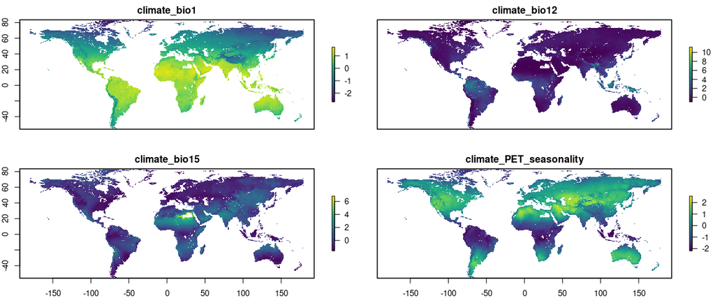

Removing unneeded objects

```r
rm(variables.df)
gc()
```

```
           used  (Mb) gc trigger   (Mb)   max used    (Mb)
Ncells  5837457 311.8   62846393 3356.4  351573305 18776.1
Vcells 71557735 546.0 1240223994 9462.2 2413810349 18416.0
```

###Reading geometry of ecoregions

The geometry of a given database table can be retrieved with `rpostgis::pgGetGeom()` as follows.

```r
#name of a ecoregion
ecoregion.target <- "Aegean and Western Turkey sclerophyllous and mixed forests"

#pulling geometry with rpostgis
ecoregion.target.geom <- rpostgis::pgGetGeom(
  conn = postgresql.connection,
  name = c("public", "ecoregions"),
  geom = "geom",
  other.cols = c("ecoregion"),
  clauses = paste(
    "WHERE ecoregion = '",
    ecoregion.target,
    "';",
    sep = ""
    )
  )
```

To simplify the process I have written the function `pull_ecoregion_geom()` located in the file functions.R acompanying this document.

```r
ecoregion.target.geom <- pull_ecoregion_geom(
  ecoregion = ecoregion.target
)
```

###Extracting raster values for an ecoregion

The values of the raster brick `variables` can be extracted for the locations of these polygons with `raster::extract()`.

```r
ecoregion.target.climate <- raster::extract(
  x = variables,
  y = ecoregion.target.geom,
  df = TRUE,
  cellnumbers = FALSE
  ) %>%
  na.omit() %>%
  dplyr::select(-ID) %>%
  dplyr::mutate(
    ecoregion = ecoregion.target
  )
str(ecoregion.target.climate)
```

To simplify the operation I have written the function `ecoregion_raster_extract` that pulls the ecoregion geom and runs the extract at once.

```r
  ecoregion.target.climate <- ecoregion_raster_extract(
  ecoregion = ecoregion.target,
  raster = variables
)
head(ecoregion.target.climate)
```

## Environmental breadth and climatic distances among ecoregions

How similar is the climate of each pair of ecoregions?

###Computing the climate hypervolume of ecoregions

```r
hv <- hypervolume::hypervolume_svm(
  data = ecoregion.target.climate[sample(
    1:nrow(ecoregion.target.climate),
    5000
    ), names(variables)],
  name = ecoregion.target,
  verbose = FALSE,
  chunk.size = 20000
  )
plot(hv)
```

The function `ecoregion_hypervolume()` returns the hypervolume of any given ecoregion by pulling its geom, extracting its raster values, and computing the hypervolume with `hypervolume::hypervolume_svm()`.

```r
hv <- ecoregion_hypervolume(
  ecoregion = ecoregion.target,
  raster = variables
)
plot(hv)
```

```r
#names of ecoregions
ecoregion_names <- RPostgreSQL::dbGetQuery(
  conn = postgresql.connection,
  statement = "SELECT ecoregion FROM ecoregions WHERE area >= 10000"
)
```

For each one of these ecoregions I use `ecoregion_hypervolume()` to compute their hypervolume, and save it in a list named `hypervolumes_ecoregions`.

```r
#list to save results
hypervolumes_ecoregions <- list()

#looping through ecoregions
for(i in 1:nrow(ecoregion_names)){

  print(paste("Iteration ", i, " of ", nrow(ecoregion_names), sep = ""))

  #getting ecoregion name
  ecoregion.name <- ecoregion_names[i, "ecoregion"]

  #computing hypervolume
  hv <- try(
    ecoregion_hypervolume(
      ecoregion = ecoregion.name,
      raster = variables
    )
  )

  #if it failed, jumps to next iteration
  if(inherits(hv, "try-error")){
    next
  } else {
    #save result
    hypervolumes_ecoregions[[ecoregion.name]] <- hv
    }

}

save(hypervolumes_ecoregions, file = "hypervolumes_ecoregions.RData")
```

### Overlap between the hypervolumes of ecoregions

The overlap between hypervolumes of two different ecoregions can be computed by first grouping both hypervolumes into a set with `hypervolume::hypervolume_set()` and then obtaining the overlap with `hypervolume::hypervolume_overlap_statistics()`. Below I show an example with two adjacent ecoregions in the Anatolian peninsula

```r
hv.a <- ecoregion_hypervolume(
  ecoregion = "Aegean and Western Turkey sclerophyllous and mixed forests",
  raster = variables
)

hv.b <- ecoregion_hypervolume(
  ecoregion = "Anatolian conifer and deciduous mixed forests",
  raster = variables
)

#set of hypervolumes
hv.set <- hypervolume::hypervolume_set(
  hv1 = hv.a,
  hv2 = hv.b,
  check.memory = FALSE
)

#overlap
hv.overlap <- hypervolume::hypervolume_overlap_statistics(hvlist = hv.set)
hv.overlap
```

```r
rm(ecoregion.data, ecoregion.names, ecoregion.target.climate, ecoregion.target.geom, hv, hv.a, hv.b, hv.set, hypervolume_ecoregions, raster, variable.selection, variables)
gc()
```

## Habitat fragmentation of ecoregions

There are ecoregions that cover extense and continuous areas, while others are heavily fragmented. To assess the degree of coherence of the different ecoregions here I use the R package `landscapemetrics` (Hesselbarth et al. 2019), that provides a large set of habitat fragmentation stats available in the traditional `FRAGSTATS` software.

Using `landscapemetrics` on the `geom` column of the `ecoregions` table requires the following steps:

- Pull the geometry with `pull_ecoregion_geom()`.
- Transform to a planar coordinate reference system in meters.
- Convert into a raster with a resolutionin meters.
- Compute metrics at the patch level, class level, or landscape level.

```
Returning MultiPolygon types in SpatialPolygons*-class.
NAs introduced by coercion
```

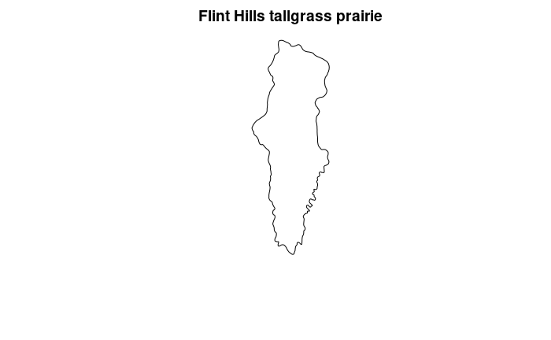

```r
ecoregion.geom <- pull_ecoregion_geom(
  ecoregion = "Flint Hills tallgrass prairie"
  ) %>%
  sp::spTransform(CRSobj = "+proj=laea")
```

```r
#list to save results
fragmentation_ecoregions <- list()

#looping through ecoregions
for(i in 1:nrow(ecoregion.names)){

  #getting ecoregion name
  ecoregion.name <- ecoregion.names[i, "ecoregion"]

  #computing fragmentation
  ef <- try(ecoregion_fragmentation(ecoregion = ecoregion.name))

  #if it failed, jumps to next iteration
  if(inherits(ef, "try-error")){
    next
  } else {
    #save result
    ef$ecoregion <- ecoregion.name
    fragmentation_ecoregions[[ecoregion.name]] <- ef
    }

}

#to dataframe
fragmentation_ecoregions <- do.call(
  "rbind",
  fragmentation_ecoregions
  ) %>%
  tidyr::pivot_wider(
    names_from = "metric",
    values_from = "value"
    ) %>%
  dplyr::rename_at(vars(ai:te), function(x){paste0("fragmentation_", x)})

#saving for later
save(fragmentation_ecoregions, file = "fragmentation_ecoregions.RData")
```

### Finding the neighbors of each ecoregion

The table `ecoregions_pairs` contains the column `connected`, that yields true when two ecoregions share a border. To find the direct neighbors of each ecoregion I subset the table where `connected` equals “true”.

```sql
CREATE TABLE ecoregions_neighbors AS
SELECT target_ecoregion AS ecoregion,
      neighbor_ecoregion AS neighbor,
      target_perimeter AS ecoregion_perimeter,
      neighbor_area,
      neighbor_perimeter,
      shared_edge_length,
      target_ecoregion_climate_aridity_index_average AS ecoregion_average_aridity,
      neighbor_ecoregion_climate_aridity_index_average AS neighbor_average_aridity,
      ecoregions.count_species AS neighbor_count_species,
      ecoregions.count_genera AS neighbor_count_genera,
      ecoregions.count_families AS neighbor_count_families,
      ecoregions.count_classes AS neighbor_count_classes,
      ecoregions.count_species_vascular AS neighbor_count_species_vascular,
      ecoregions.count_genera_vascular AS neighbor_count_genera_vascular,
      ecoregions.count_families_vascular AS neighbor_count_families_vascular,
      ecoregions.count_classes_vascular AS neighbor_count_classes_vascular,
      ecoregions.count_phyla AS neighbor_count_phyla
FROM ecoregions_pairs, ecoregions
WHERE connected = 'true'
AND ecoregions_pairs.neighbor_ecoregion = ecoregions.ecoregion
ORDER BY ecoregion, neighbor;
```

```sql
ALTER TABLE ecoregions
ADD COLUMN neighbors_count integer;

ALTER TABLE ecoregions
ADD COLUMN neighbors_area_sum numeric;

ALTER TABLE ecoregions
ADD COLUMN neighbors_percentage_shared_edge numeric;

ALTER TABLE ecoregions
ADD COLUMN neighbors_average_aridity numeric;

ALTER TABLE ecoregions
ADD COLUMN neighbors_species_count_average numeric;

ALTER TABLE ecoregions
ADD COLUMN neighbors_genera_count_average numeric;

ALTER TABLE ecoregions
ADD COLUMN neighbors_families_count_average numeric;

ALTER TABLE ecoregions
ADD COLUMN neighbors_classes_count_average numeric;

ALTER TABLE ecoregions
ADD COLUMN neighbors_phyla_count_average numeric;

ALTER TABLE ecoregions
ADD COLUMN neighbors_species_vascular_count_average numeric;

ALTER TABLE ecoregions
ADD COLUMN neighbors_genera_vascular_count_average numeric;

ALTER TABLE ecoregions
ADD COLUMN neighbors_families_vascular_count_average numeric;

ALTER TABLE ecoregions
ADD COLUMN neighbors_classes_vascular_count_average numeric;
```

```sql
UPDATE ecoregions
SET
neighbors_count = temp.neighbors_count,
neighbors_area_sum = temp.neighbors_area_sum,
neighbors_percentage_shared_edge = temp.neighbors_percentage_shared_edge,
neighbors_average_aridity = temp.neighbors_average_aridity,
neighbors_species_count_average = temp.neighbors_species_count_average,
neighbors_genera_count_average = temp.neighbors_genera_count_average,
neighbors_families_count_average = temp.neighbors_families_count_average,
neighbors_classes_count_average = temp.neighbors_classes_count_average,
neighbors_phyla_count_average = temp.neighbors_phyla_count_average,
neighbors_species_vascular_count_average = temp.neighbors_species_vascular_count_average,
neighbors_genera_vascular_count_average = temp.neighbors_genera_vascular_count_average,
neighbors_families_vascular_count_average = temp.neighbors_families_vascular_count_average,
neighbors_classes_vascular_count_average = temp.neighbors_classes_vascular_count_average
FROM
(
SELECT
ecoregion,
COUNT(neighbor) AS neighbors_count,
SUM(neighbor_area) AS neighbors_area_sum,
(SUM(shared_edge_length) * 100) / ecoregion_perimeter AS neighbors_percentage_shared_edge,
AVG(neighbor_average_aridity) AS neighbors_average_aridity,
AVG(neighbor_count_species) AS neighbors_species_count_average,
AVG(neighbor_count_genera) AS neighbors_genera_count_average,
AVG(neighbor_count_families) AS neighbors_families_count_average,
AVG(neighbor_count_classes) AS neighbors_classes_count_average,
AVG(neighbor_count_species_vascular) AS neighbors_species_vascular_count_average,
AVG(neighbor_count_genera_vascular) AS neighbors_genera_vascular_count_average,
AVG(neighbor_count_families_vascular) AS neighbors_families_vascular_count_average,
AVG(neighbor_count_classes_vascular) AS neighbors_classes_vascular_count_average,
AVG(neighbor_count_phyla) AS neighbors_phyla_count_average
FROM ecoregions_neighbors
GROUP BY ecoregion, ecoregion_perimeter
) temp
WHERE temp.ecoregion = ecoregions.ecoregion;
```

A list with ecoregions with no neighbors is needed as well for subsetting purposes.

```sql
CREATE TABLE ecoregions_isolated AS
SELECT DISTINCT ecoregions.ecoregion
FROM ecoregions, ecoregions_neighbors
WHERE ecoregions.ecoregion NOT IN (
SELECT ecoregion
FROM ecoregions_neighbors
)
ORDER BY ecoregion;
```

## Computing betadiversity scores between ecoregions

To compute betadiversity scores I first load the required tables into the R environment. In this step I will change the names of several columns to better represent the underlying structure of the data.

```r
ecoregions <- DBI::dbGetQuery(
  postgresql.connection,
  "SELECT
  ecoregion AS ecoregion_name,
  biome AS ecoregion_biome,
  realm AS ecoregion_realm,
  continent AS ecoregion_continent,
  area AS ecoregion_area_km2,
  count_records AS bias_records,
  records_per_km2 AS bias_records_per_km2,
  count_species / count_records AS bias_species_per_record,
  count_species / records_per_km2 AS bias_species_per_record_per_km2,
  count_species AS richness_species,
  count_genera AS richness_genera,
  count_families AS richness_families,
  count_classes AS richness_classes,
  count_phyla AS richness_phyla,
  count_species_vascular AS richness_species_vascular,
  count_genera_vascular AS richness_genera_vascular,
  count_families_vascular AS richness_families_vascular,
  count_classes_vascular AS richness_classes_vascular,
  neighbors_count,
  neighbors_area_sum AS neighbors_area,
  neighbors_percentage_shared_edge,
  neighbors_average_aridity,
  neighbors_species_count_average,
  neighbors_genera_count_average,
  neighbors_families_count_average,
  neighbors_classes_count_average,
  conservation_assessment AS human_conservation_assessment,
  human_population,
  human_population_density,
  human_footprint_minimum,
  human_footprint_maximum,
  human_footprint_average,
  climate_aridity_index_minimum,
  climate_aridity_index_maximum,
  climate_aridity_index_average,
  climate_bio1_minimum,
  climate_bio1_maximum,
  climate_bio1_average,
  climate_bio4_minimum,
  climate_bio4_maximum,
  climate_bio4_average,
  climate_bio5_minimum,
  climate_bio5_maximum,
  climate_bio5_average,
  climate_bio12_minimum,
  climate_bio12_maximum,
  climate_bio12_average,
  climate_bio15_minimum,
  climate_bio15_maximum,
  climate_bio15_average,
  climate_growing_degree_days_5_minimum,
  climate_growing_degree_days_5_maximum,
  climate_growing_degree_days_5_average,
  climate_velocity_lgm_minimum,
  climate_velocity_lgm_maximum,
  climate_velocity_lgm_average,
  landcover_bare_soil_percent_minimum AS landcover_bare_percent_minimum,
  landcover_bare_soil_percent_maximum AS landcover_bare_percent_maximum,
  landcover_bare_soil_percent_average AS landcover_bare_percent_average,
  landcover_herbaceous_percent_minimum AS landcover_herbs_percent_minimum,
  landcover_herbaceous_percent_maximum AS landcover_herbs_percent_maximum,
  landcover_herbaceous_percent_average AS landcover_herbs_percent_average,
  landcover_trees_percent_minimum,
  landcover_trees_percent_maximum,
  landcover_trees_percent_average,
  ndvi_min_minimum AS landcover_ndvi_minimum,
  ndvi_max_maximum AS landcover_ndvi_maximum,
  (ndvi_min_average + ndvi_max_average) / 2 AS landcover_ndvi_average,
  geo_latitude_average,
  geo_latitude_range,
  geo_longitude_average,
  geo_longitude_range,
  topography_elevation_minimum,
  topography_elevation_maximum,
  topography_elevation_average,
  topography_elevation_range
  FROM ecoregions;"
  )
```

To read `ecoregions_pairs`:

```r
ecoregions_pairs <- DBI::dbGetQuery(
  postgresql.connection,
  "SELECT
  target_ecoregion AS ecoregion_name,
  neighbor_ecoregion AS neighbor_name,
  target_area AS ecoregion_area,
  neighbor_area,
  target_ecoregion_climate_aridity_index_average AS ecoregion_climate_aridity_index_average,
 neighbor_ecoregion_climate_aridity_index_average AS neighbor_climate_aridity_index_average,
 target_ecoregion_geo_latitude_average AS ecoregion_geo_latitude_average,
 neighbor_ecoregion_geo_latitude_average AS neighbor_geo_latitude_average,
  target_ecoregion_geo_longitude_average AS ecoregion_geo_longitude_average,
 neighbor_ecoregion_geo_longitude_average AS neighbor_geo_longitude_average,
   target_ecoregion_topography_elevation_average AS ecoregion_topography_elevation_average,
 neighbor_ecoregion_topography_elevation_average AS neighbor_topography_elevation_average,
 same_biome AS connection_same_biome,
 same_realm AS connection_same_realm,
 same_continent AS connection_same_continent,
 geographic_distance_km AS connection_distance,
 connected AS connection_are_neighbors,
 shared_edge_length AS connection_shared_edge,
 geo_latitude_diff AS connection_latitude_diff,
 geo_longitude_diff AS connection_longitude_diff,
 area_diff AS connection_area_diff,
 count_species_diff AS richness_species_diff,
 count_genera_diff AS richness_genera_diff,
 count_families_diff AS richness_families_diff,
 count_classes_diff AS richness_classes_diff,
 count_species_vascular_diff AS richness_species_vascular_diff,
 count_genera_vascular_diff AS richness_genera_vascular_diff,
 count_families_vascular_diff AS richness_families_vascular_diff,
 count_classes_vascular_diff AS richness_classes_vascular_diff,
 climate_aridity_index_diff,
 climate_bio1_average_diff,
 climate_bio4_average_diff,
 climate_bio5_average_diff,
 climate_bio12_average_diff,
 climate_bio15_average_diff,
 climate_velocity_lgm_average_diff,
 human_footprint_average_diff,
 human_population_diff,
 human_population_density_diff,
 landcover_bare_soil_percent_average_diff AS landcover_bare_percent_average_diff,
 landcover_herbaceous_percent_average_diff AS landcover_herbs_percent_average_diff,
 landcover_trees_percent_average_diff,
 ndvi_min_diff AS landcover_ndvi_min_diff,
 ndvi_max_diff AS landcover_ndvi_max_diff,
 topography_elevation_diff
 FROM ecoregions_pairs;"
  )
```

To read `ecoregions_neighbors`:

```r
ecoregions_neighbors <- DBI::dbGetQuery(
  postgresql.connection,
  "SELECT
  ecoregion,
  neighbor
  FROM ecoregions_neighbors;"
  )
```

To read the tables with the species, genera, families and classes identified on each ecoregion.

```r
ecoregions_species  <- DBI::dbGetQuery(
  postgresql.connection,
  "SELECT * FROM ecoregions_species;"
  )

ecoregions_species_taxonomy  <- DBI::dbGetQuery(
  postgresql.connection,
  "SELECT * FROM ecoregions_species_taxonomy;"
  )

ecoregions_genera  <- DBI::dbGetQuery(
  postgresql.connection,
  "SELECT * FROM ecoregions_genera;"
  )

ecoregions_families  <- DBI::dbGetQuery(
  postgresql.connection,
  "SELECT * FROM ecoregions_families;"
  )

ecoregions_classes  <- DBI::dbGetQuery(
  postgresql.connection,
  "SELECT * FROM ecoregions_classes;"
  )

ecoregions_species_vascular  <- DBI::dbGetQuery(
  postgresql.connection,
  "SELECT * FROM ecoregions_species_vascular;"
  )

ecoregions_genera_vascular  <- DBI::dbGetQuery(
  postgresql.connection,
  "SELECT * FROM ecoregions_genera_vascular;"
  )

ecoregions_families_vascular  <- DBI::dbGetQuery(
  postgresql.connection,
  "SELECT * FROM ecoregions_families_vascular;"
  )

ecoregions_classes  <- DBI::dbGetQuery(
  postgresql.connection,
  "SELECT * FROM ecoregions_classes_vascular;"
  )

species <- DBI::dbGetQuery(
  postgresql.connection,
  "SELECT
  class,
  family,
  genus,
  species,
  spatial_records
  FROM species;"
  )
```

##Adding tree species

```r
#loading the tree database from https://tools.bgci.org/global_tree_search.php
trees <- data.table::fread(
  "global_tree_search_trees_1_4.csv",
  header = TRUE)[, 1]
colnames(trees) <- "species"

#getting unique species in ecoregions_species
gbif.species <- unique(ecoregions_species$species)

#separating the dataframe in species with the same name in ecoregions_species
trees.ready <- trees[trees$species %in% gbif.species, ]
trees.not.ready <- trees[!(trees$species %in% gbif.species), ]
rm(trees)

#finding gbif synonym for trees in trees.not.ready
trees.not.ready$synonym <- "none"

for(species.i in trees.not.ready$species){

  #retrieving synonyms
  synonyms.i <- rgbif::name_backbone(
    name = species.i,
    kingdom = "Plantae",
    verbose=TRUE)$data %>%
    as.data.frame()

  #if nothing found
  if(synonyms.i$matchType == "NONE"){
    next
  #if synonyms found
  } else {

    #iterate through synonyms to find them in gbif.species
    for(synonym.i in synonyms.i[, "canonicalName"]){

      #chdk if synonym is in gbif.species
      if(synonym.i %in% gbif.species){

        #write it in the synonyms column
        trees.not.ready[
          trees.not.ready$species == species.i,
          "synonym"] <- synonym.i

        #break loop
        break

      }
    }
  }
}

#how many species have I salvaged with this
sum(trees.not.ready$synonym != "none")
```

```
[1] 325
```

```r
#325...

#preparing to join with trees.ready
trees.not.ready <- trees.not.ready[
        trees.not.ready$synonym != "none",
        "synonym"
        ]
colnames(trees.not.ready) <- "species"

#joining with trees.ready
trees.ready <- rbind(
  trees.ready,
  trees.not.ready
)

#adding boolean column
trees.ready$is.tree <- TRUE

#adding is.tree to ecoregions_species_taxonomy
ecoregions_species_taxonomy <- dplyr::left_join(
  x = ecoregions_species_taxonomy,
  y = trees.ready,
  by = "species"
)
ecoregions_species_taxonomy[
  is.na(ecoregions_species_taxonomy$is.tree),
  "is.tree"
  ] <- FALSE

#adding grasses
ecoregions_species_taxonomy$is.grass <- FALSE
ecoregions_species_taxonomy[
  ecoregions_species_taxonomy$family == "Poaceae",
  "is.grass"
  ] <- TRUE

#generating the ecoregions_x tables
ecoregions_species_trees <- ecoregions_species_taxonomy[
  ecoregions_species_taxonomy$is.tree == TRUE,
  c("ecoregion", "species")
]

ecoregions_genera_trees <- ecoregions_species_taxonomy[
  ecoregions_species_taxonomy$is.tree == TRUE,
  c("ecoregion", "genus")
] %>%
  dplyr::distinct()

ecoregions_families_trees <- ecoregions_species_taxonomy[
  ecoregions_species_taxonomy$is.tree == TRUE,
  c("ecoregion", "family")
] %>%
  dplyr::distinct()

ecoregions_species_grasses <- ecoregions_species_taxonomy[
  ecoregions_species_taxonomy$is.grass == TRUE,
  c("ecoregion", "species")
]

ecoregions_genera_grasses<- ecoregions_species_taxonomy[
  ecoregions_species_taxonomy$is.grass == TRUE,
  c("ecoregion", "genus")
] %>%
  dplyr::distinct()
```

## Completing the `ecoregions` table

The richness values for trees and grasses need to be added to the `ecoregions` table. First I add the columns.

```r
#adding the columns
ecoregions <- tibble::add_column(ecoregions, richness_species_trees = NA, .before = "neighbors_count")
ecoregions <- tibble::add_column(ecoregions, richness_genera_trees = NA, .before = "neighbors_count")
ecoregions <- tibble::add_column(ecoregions, richness_families_trees = NA, .before = "neighbors_count")
ecoregions <- tibble::add_column(ecoregions, richness_species_grasses = NA, .before = "neighbors_count")
ecoregions <- tibble::add_column(ecoregions, richness_genera_grasses = NA, .before = "neighbors_count")
```

And then fill them line by line

```r
for(i in 1:nrow(ecoregions)){

  #getting ecoregion name
  ecoregion.i <- ecoregions[i, "ecoregion_name"]

  #filling richness values
  ecoregions[i, "richness_species_trees"] <- nrow(ecoregions_species_trees[ecoregions_species_trees$ecoregion == ecoregion.i, ])
  ecoregions[i, "richness_genera_trees"] <- nrow(ecoregions_genera_trees[ecoregions_genera_trees$ecoregion == ecoregion.i, ])
  ecoregions[i, "richness_families_trees"] <- nrow(ecoregions_families_trees[ecoregions_families_trees$ecoregion == ecoregion.i, ])
  ecoregions[i, "richness_species_grasses"] <- nrow(ecoregions_species_grasses[ecoregions_species_grasses$ecoregion == ecoregion.i, ])
  ecoregions[i, "richness_genera_grasses"] <- nrow(ecoregions_genera_grasses[ecoregions_genera_grasses$ecoregion == ecoregion.i, ])

}
```

### Assessing the rarity of species, genuses, and families

Species rarity is an important biodiversity dimension.

**Rarity weighted richness** (RWR, Williams et al., 1996)

```r
ecoregions <- tibble::add_column(ecoregions, rarity_species_by_presence = NA, .before = "neighbors_count")
ecoregions <- tibble::add_column(ecoregions, rarity_species_by_ecoregion = NA, .before = "neighbors_count")
ecoregions <- tibble::add_column(ecoregions, rarity_species_vascular_by_presence = NA, .before = "neighbors_count")
ecoregions <- tibble::add_column(ecoregions, rarity_species_vascular_by_ecoregion = NA, .before = "neighbors_count")
ecoregions <- tibble::add_column(ecoregions, rarity_genera_by_presence = NA, .before = "neighbors_count")
ecoregions <- tibble::add_column(ecoregions, rarity_genera_by_ecoregion = NA, .before = "neighbors_count")
ecoregions <- tibble::add_column(ecoregions, rarity_genera_vascular_by_presence = NA, .before = "neighbors_count")
ecoregions <- tibble::add_column(ecoregions, rarity_genera_vascular_by_ecoregion = NA, .before = "neighbors_count")
ecoregions <- tibble::add_column(ecoregions, rarity_species_trees_by_presence = NA, .before = "neighbors_count")
ecoregions <- tibble::add_column(ecoregions, rarity_species_trees_by_ecoregion = NA, .before = "neighbors_count")
ecoregions <- tibble::add_column(ecoregions, rarity_genera_trees_by_presence = NA, .before = "neighbors_count")
ecoregions <- tibble::add_column(ecoregions, rarity_genera_trees_by_ecoregion = NA, .before = "neighbors_count")
ecoregions <- tibble::add_column(ecoregions, rarity_species_grasses_by_presence = NA, .before = "neighbors_count")
ecoregions <- tibble::add_column(ecoregions, rarity_species_grasses_by_ecoregion = NA, .before = "neighbors_count")
ecoregions <- tibble::add_column(ecoregions, rarity_genera_grasses_by_presence = NA, .before = "neighbors_count")
ecoregions <- tibble::add_column(ecoregions, rarity_genera_grasses_by_ecoregion = NA, .before = "neighbors_count")
```

Then I iterate line by line to compute the rarity of each taxa pool.

```r
for(i in 1:nrow(ecoregions)){

  #getting ecoregion name
  ecoregion.i <- ecoregions[i, "ecoregion_name"]

  #rarity species by presence
  ecoregions[i, "rarity_species_by_presence"] <- sum(1 / dplyr::left_join(x = ecoregions_species[ecoregions_species$ecoregion == ecoregion.i,], y = species[, c("species", "spatial_records")], by = "species") %>% dplyr::pull(spatial_records))

    ecoregions[i, "rarity_species_vascular_by_presence"] <- sum(1 / dplyr::left_join(x = ecoregions_species_vascular[ecoregions_species_vascular$ecoregion == ecoregion.i,], y = species[, c("species", "spatial_records")], by = "species") %>% dplyr::pull(spatial_records))

  #
  ecoregions[i, "rarity_species_trees_by_presence"] <- sum(1 / dplyr::left_join(x = ecoregions_species_trees[ecoregions_species_trees$ecoregion == ecoregion.i,], y = species[, c("species", "spatial_records")], by = "species") %>% dplyr::pull(spatial_records))

  #
  ecoregions[i, "rarity_species_grasses_by_presence"] <- sum(1 / dplyr::left_join(x = ecoregions_species_grasses[ecoregions_species_grasses$ecoregion == ecoregion.i,], y = species[, c("species", "spatial_records")], by = "species") %>% dplyr::pull(spatial_records))

  #rarity genera by presence
  #
  ecoregions[i, "rarity_genera_by_presence"]  <-  sum( 1 / species %>% dplyr::filter(genus %in% ecoregions_genera[ecoregions_genera$ecoregion == ecoregion.i, "genus"]) %>% dplyr::group_by(genus) %>% dplyr::summarise(spatial_records = sum(spatial_records)) %>% dplyr::pull(spatial_records))

  #
  ecoregions[i, "rarity_genera_vascular_by_presence"]  <-  sum( 1 / species %>% dplyr::filter(genus %in% ecoregions_genera_vascular[ecoregions_genera_vascular$ecoregion == ecoregion.i, "genus"]) %>% dplyr::group_by(genus) %>% dplyr::summarise(spatial_records = sum(spatial_records)) %>% dplyr::pull(spatial_records))

  #
  ecoregions[i, "rarity_genera_trees_by_presence"] <-  sum(1 / species %>% dplyr::filter(genus %in% ecoregions_genera_trees[ecoregions_genera_trees$ecoregion == ecoregion.i, "genus"]) %>% dplyr::group_by(genus) %>% dplyr::summarise(spatial_records = sum(spatial_records)) %>% dplyr::pull(spatial_records))

  #
  ecoregions[i, "rarity_genera_grasses_by_presence"] <- sum(1 / species %>% dplyr::filter(genus %in% ecoregions_genera_grasses[ecoregions_genera_grasses$ecoregion == ecoregion.i, "genus"]) %>% dplyr::group_by(genus) %>% dplyr::summarise(spatial_records = sum(spatial_records)) %>% dplyr::pull(spatial_records))


  #rarity species by ecoregion
  ecoregions[i, "rarity_species_by_ecoregion"] <- sum(1 /
    ecoregions_species %>% dplyr::filter(species %in% ecoregions_species[ecoregions_species$ecoregion == ecoregion.i, "species"]) %>% dplyr::group_by(species) %>% dplyr::summarise(n_ecoregions = n()) %>% dplyr::pull(n_ecoregions))

  #
  ecoregions[i, "rarity_species_vascular_by_ecoregion"] <- sum(1 /
    ecoregions_species_vascular %>% dplyr::filter(species %in% ecoregions_species_vascular[ecoregions_species_vascular$ecoregion == ecoregion.i, "species"]) %>% dplyr::group_by(species) %>% dplyr::summarise(n_ecoregions = n()) %>% dplyr::pull(n_ecoregions))

  #
  ecoregions[i, "rarity_species_trees_by_ecoregion"] <- sum(1 /
    ecoregions_species_trees %>% dplyr::filter(species %in% ecoregions_species_trees[ecoregions_species_trees$ecoregion == ecoregion.i, "species"]) %>% dplyr::group_by(species) %>% dplyr::summarise(n_ecoregions = n()) %>% dplyr::pull(n_ecoregions))

  #
  ecoregions[i, "rarity_species_grasses_by_ecoregion"] <- sum(1 /
    ecoregions_species_grasses %>% dplyr::filter(species %in% ecoregions_species_grasses[ecoregions_species_grasses$ecoregion == ecoregion.i, "species"]) %>% dplyr::group_by(species) %>% dplyr::summarise(n_ecoregions = n()) %>% dplyr::pull(n_ecoregions))

  #rarity by genus and ecoregion

  #
  ecoregions[i, "rarity_genera_by_ecoregion"] <- sum(1 /
    ecoregions_genera %>% dplyr::filter(genus %in% ecoregions_genera[ecoregions_genera$ecoregion == ecoregion.i, "genus"]) %>% dplyr::group_by(genus) %>% dplyr::summarise(n_ecoregions = n()) %>% dplyr::pull(n_ecoregions))

  #
  ecoregions[i, "rarity_genera_vascular_by_ecoregion"] <- sum(1 /
    ecoregions_genera_vascular %>% dplyr::filter(genus %in% ecoregions_genera_vascular[ecoregions_genera_vascular$ecoregion == ecoregion.i, "genus"]) %>% dplyr::group_by(genus) %>% dplyr::summarise(n_ecoregions = n()) %>% dplyr::pull(n_ecoregions))

  #
  ecoregions[i, "rarity_genera_trees_by_ecoregion"] <- sum(1 /
    ecoregions_genera_trees %>% dplyr::filter(genus %in% ecoregions_genera_trees[ecoregions_genera_trees$ecoregion == ecoregion.i, "genus"]) %>% dplyr::group_by(genus) %>% dplyr::summarise(n_ecoregions = n()) %>% dplyr::pull(n_ecoregions))

  #
  ecoregions[i, "rarity_genera_grasses_by_ecoregion"] <-  sum(1 /
    ecoregions_genera_grasses %>% dplyr::filter(genus %in% ecoregions_genera_grasses[ecoregions_genera_grasses$ecoregion == ecoregion.i, "genus"]) %>% dplyr::group_by(genus) %>% dplyr::summarise(n_ecoregions = n()) %>% dplyr::pull(n_ecoregions))


}
```

To compute the percentag of exclusive species, genera, and families…

```r
ecoregions <- tibble::add_column(ecoregions, exclusive_species = NA, .before = "neighbors_count")
ecoregions <- tibble::add_column(ecoregions, exclusive_species_percentage = NA, .before = "neighbors_count")
ecoregions <- tibble::add_column(ecoregions, exclusive_genera = NA, .before = "neighbors_count")
ecoregions <- tibble::add_column(ecoregions, exclusive_genera_percentage = NA, .before = "neighbors_count")
ecoregions <- tibble::add_column(ecoregions, exclusive_species_vascular = NA, .before = "neighbors_count")
ecoregions <- tibble::add_column(ecoregions, exclusive_species_vascular_percentage = NA, .before = "neighbors_count")
ecoregions <- tibble::add_column(ecoregions, exclusive_genera_vascular = NA, .before = "neighbors_count")
ecoregions <- tibble::add_column(ecoregions, exclusive_genera_vascular_percentage = NA, .before = "neighbors_count")
ecoregions <- tibble::add_column(ecoregions, exclusive_species_trees = NA, .before = "neighbors_count")
ecoregions <- tibble::add_column(ecoregions, exclusive_species_trees_percentage = NA, .before = "neighbors_count")
ecoregions <- tibble::add_column(ecoregions, exclusive_genera_trees = NA, .before = "neighbors_count")
ecoregions <- tibble::add_column(ecoregions, exclusive_genera_trees_percentage = NA, .before = "neighbors_count")
ecoregions <- tibble::add_column(ecoregions, exclusive_species_grasses = NA, .before = "neighbors_count")
ecoregions <- tibble::add_column(ecoregions, exclusive_species_grasses_percentage = NA, .before = "neighbors_count")
ecoregions <- tibble::add_column(ecoregions, exclusive_genera_grasses = NA, .before = "neighbors_count")
ecoregions <- tibble::add_column(ecoregions, exclusive_genera_grasses_percentage = NA, .before = "neighbors_count")
```

```r
for(i in 1:nrow(ecoregions)){

  #getting ecoregion name
  ecoregion.i <- ecoregions[i, "ecoregion_name"]

  #number and percentage of exclusive species
  ecoregions[i, "exclusive_species"] <- sum(table(ecoregions_species$species[ecoregions_species$species %in% ecoregions_species[ecoregions_species$ecoregion == ecoregion.i, "species"]]) == 1)

  ecoregions[i, "exclusive_species_percentage"] <- (ecoregions[i, "exclusive_species"] * 100) / ecoregions[i, "richness_species"]

  #number and percentage of exclusive genera
  ecoregions[i, "exclusive_genera"] <- sum(table(ecoregions_genera$genus[ecoregions_genera$genus %in% ecoregions_genera[ecoregions_genera$ecoregion == ecoregion.i, "genus"]]) == 1)

  ecoregions[i, "exclusive_genera_percentage"] <- (ecoregions[i, "exclusive_genera"] * 100) / ecoregions[i, "richness_genera"]

  #number and percentage of exclusive vascular species
  ecoregions[i, "exclusive_species_vascular"] <- sum(table(ecoregions_species_vascular$species[ecoregions_species_vascular$species %in% ecoregions_species_vascular[ecoregions_species_vascular$ecoregion == ecoregion.i, "species"]]) == 1)

  ecoregions[i, "exclusive_species_vascular_percentage"] <- (ecoregions[i, "exclusive_species_vascular"] * 100) / ecoregions[i, "richness_species_vascular"]

    #number and percentage of exclusive vascular genera
  ecoregions[i, "exclusive_genera_vascular"] <- sum(table(ecoregions_genera_vascular$genus[ecoregions_genera_vascular$genus %in% ecoregions_genera_vascular[ecoregions_genera_vascular$ecoregion == ecoregion.i, "genus"]]) == 1)

  ecoregions[i, "exclusive_genera_vascular_percentage"] <- (ecoregions[i, "exclusive_genera_vascular"] * 100) / ecoregions[i, "richness_genera"]

  #number and percentage of exclusive tree species
  ecoregions[i, "exclusive_species_trees"] <- sum(table(ecoregions_species_trees$species[ecoregions_species_trees$species %in% ecoregions_species_trees[ecoregions_species_trees$ecoregion == ecoregion.i, "species"]]) == 1)

  ecoregions[i, "exclusive_species_trees_percentage"] <- (ecoregions[i, "exclusive_species_trees"] * 100) / ecoregions[i, "richness_species_trees"]

  #number and percentage of exclusive tree genera
  ecoregions[i, "exclusive_genera_trees"] <- sum(table(ecoregions_genera_trees$genus[ecoregions_genera_trees$genus %in% ecoregions_genera_trees[ecoregions_genera_trees$ecoregion == ecoregion.i, "genus"]]) == 1)

  ecoregions[i, "exclusive_genera_trees_percentage"] <- (ecoregions[i, "exclusive_genera_trees"] * 100) / ecoregions[i, "richness_genera_trees"]

    #number and percentage of exclusive grasses species
  ecoregions[i, "exclusive_species_grasses"] <- sum(table(ecoregions_species_grasses$species[ecoregions_species_grasses$species %in% ecoregions_species_grasses[ecoregions_species_grasses$ecoregion == ecoregion.i, "species"]]) == 1)

  ecoregions[i, "exclusive_species_grasses_percentage"] <- (ecoregions[i, "exclusive_species_grasses"] * 100) / ecoregions[i, "richness_species_grasses"]

    #number and percentage of exclusive grasses genera
  ecoregions[i, "exclusive_genera_grasses"] <- sum(table(ecoregions_genera_grasses$genus[ecoregions_genera_grasses$genus %in% ecoregions_genera_grasses[ecoregions_genera_grasses$ecoregion == ecoregion.i, "genus"]]) == 1)

  ecoregions[i, "exclusive_genera_grasses_percentage"] <- (ecoregions[i, "exclusive_genera_grasses"] * 100) / ecoregions[i, "richness_genera_grasses"]


}
```

The habitat fragmentation measures computed above have to be added to the table `ecoregions`. Also, there are a few data gaps in the `ecoregions` table, particularly for these ecoregions that do not have direct neighbors.

```r
#loading fragmentation data
load("fragmentation_ecoregions.RData")

#joining it with the ecoregions table
ecoregions <-
  ecoregions %>%
  dplyr::left_join(
  y = fragmentation_ecoregions,
  by = c("ecoregion_name" = "ecoregion")
)


rm(fragmentation_ecoregions)
```

The table ecoregions also has gaps in the `neighbors_x` fields for these ecoregions that have no direct neighbors because they are surrounded by the ocean. Here, to fill these gaps, I replace direct neighbors with neighboring ecoregions that are at a distance of 1000 km or less.

The fields to fill are:

- `neighbors_count`
- `neighbors_area`
- `neighbors_percentage_shared_edge` (must be set to 0)
- `neighbors_average_aridity`
- `neighbors_species_count_average`
- `neighbors_genera_count_average`
- `neighbors_families_count_average`
- `neighbors_classes_count_average`

Below I iterate through each record in `ecoregions`, and for each record with `NA` in `neighbors_count` I retrieve the neighboring ecoregions within 1000 km to compute and fill the missing values. I take advantage of this loop to add to each ecoregion its environmental hypervolume, stored in *hypervolumes_ecoregions.RData*

```r
#loading hypervolumes
load("hypervolumes_ecoregions.RData")

#creating hypervolume
ecoregions$climate_hypervolume <- NA

#iterating through ecoregions
for(i in 1:nrow(ecoregions)){

  #getting ecoregion name
  ecoregion.i <- ecoregions[i, "ecoregion_name"]

  #adding climate hypervolume
  if(ecoregion.i %in% names(hypervolumes_ecoregions)){
    ecoregions[i, "climate_hypervolume"] <- hypervolume::get_volume(hypervolumes_ecoregions[[ecoregion.i]])
  }

  #if there are gaps to fill
  if(is.na(ecoregions[i, "neighbors_count"])){

    #retrieving neighbors
    neighbors.i <- dplyr::filter(
      ecoregions_pairs,
      ecoregion_name == ecoregion.i,
      connection_distance <= 1000
    ) %>%
      dplyr::pull(neighbor_name)

    #next if empty
    if(length(neighbors.i) == 0){next}

    #indices of rows in ecoregions
    indices.i <- which(ecoregions$ecoregion_name %in% neighbors.i)

    #filling empty columns
   ecoregions[i, "neighbors_count"] <- length(neighbors.i)

   ecoregions[i, "neighbors_area"] <- sum(ecoregions[
     indices.i,
     "ecoregion_area_km2"
   ])

   ecoregions[i, "neighbors_percentage_shared_edge"] <- 0

   ecoregions[i, "neighbors_average_aridity"] <- mean(ecoregions[
     indices.i,
     "climate_aridity_index_average"
   ])

   ecoregions[i, "neighbors_species_count_average"] <- mean(ecoregions[
     indices.i,
     "richness_species"
   ])

   ecoregions[i, "neighbors_genera_count_average"] <- mean(ecoregions[
     indices.i,
     "richness_genera"
   ])

   ecoregions[i, "neighbors_families_count_average"] <- mean(ecoregions[
     indices.i,
     "richness_families"
   ])

  ecoregions[i, "neighbors_classes_count_average"] <- mean(ecoregions[
     indices.i,
     "richness_classes"
   ])

  } else {
    next
  }

}
```

## Computation of betadiversity scores

For the table `ecoregions` I compute betadiversity between each ecoregion and its immediate neighbors.

To exemplify how to compute betadiversity scores here I take two neighboring ecoregions: “North Western Ghats moist deciduous forests” (`eco1`) and “South Deccan Plateau dry deciduous forests” (`eco2`).

I first compute `a` as the the number of species common both sites, whereas `b` and `c`, respectively, are the number of exclusive species of each site.

```r
#number of species of each site
length(eco1)
```

```
[1] 954
```

```r
length(eco2)
```

```
[1] 1373
```

```r
#extracting betadiversity components
a <- length(intersect(eco1, eco2))
b <- length(setdiff(eco1, eco2))
c <- length(setdiff(eco2, eco1))

#extracting betadiversity components as proportion of the complete species pool
a. <- (a * 100) / (a + b + c)
b. <- (b * 100) / (a + b + c)
c. <- (c * 100) / (a + b + c)
```

There is a large number of betadiversity measures. Here I use four compute:

**COPIED FROM BENITO ET AL. 2013** We examined Koleff, Gaston & Lennon (2003) searching for indexes with different properties and selected two of them: (1) the Sorensen similarity index (bsor), presented by Lennon et al. (2001), is a measure of continuity that depends on the variation of the matching component a. To allow the comparison of bsor with the other indexes, we transformed its values into dissimilarity by subtracting the equation in Koleff, Gaston & Lennon (2003) by one (see Eq. 3). According to Eq. 3, bsor has its upper limit at one (strong dissimilarity between compositions) and the lower limit at zero (strong similarity between compositions); (2) the symmetric form of the Simpson’s dissimilarity index (bsim, Eq. 4), that was also presented in Lennon et al. (2001), derived from the one proposed by Simpson (1943), and reformulated by Koleff, Gaston & Lennon (2003). bsim is a measure of turnover focused on compositional differences instead of differences in species richness. The upper bsim value is found when the observed and predicted compositions have no species in common, and the lower value is zero, when both compositions are the same.

- **Richness similarity**, computed as $R = |(a + b) - (a + c)|$ for the raw version, and $R. = |(a. + b.) - (a. + c.)|$ for the percentage version.
- **Composition similarity**, computed as $C = (b + c) / a$ for the raw species numbers. Not computed for species percentages because it yields the same result.
- **Sorensen similarity index** (Lennon et al. 2001), computed as $Bsor = 1 - (2a / (2a + b + c))$ for the raw numbers, and not computed for the species percentages.
- **Simpson’s dissimilarity index** (Lennon et al. 2001), computed as $Bsim = min(b, c) / (min(b, c) + a)$ for the raw numbers only (yields same result with percentages of the total species pool.)

```r
R <- abs((a + b) - (a + c))
R. <- abs((a. + b.) - (a. + c.))

C <- (b + c) / a
C. <- (b. + c.) / a.
```

The custom function `betadiversity()` performs the computation for any given pair of ecoregions, as follows:

```r
x <- betadiversity(
  ecoregion.1 = "North Western Ghats moist deciduous forests",
  ecoregion.2 = "South Deccan Plateau dry deciduous forests",
  taxa.list = ecoregions_species,
  taxa.column = "species"
)
x
```

```
          a           b           c   a_percent   b_percent   c_percent           R
397.0000000 557.0000000 976.0000000  20.5699482  28.8601036  50.5699482 419.0000000
  R_percent           C        Bsor        Bsim
 21.7098446   3.8614610   0.6587881   0.5838574
```

The same can be done between an ecoregion and a group of ecoregions and different taxonomic levels.

```r
x <- betadiversity(
  ecoregion.1 = "Central Deccan Plateau dry deciduous forests",
  ecoregion.2 = c(
    "South Deccan Plateau dry deciduous forests",
    "North Western Ghats moist deciduous forests"
    ),
  taxa.list = ecoregions_genera,
  taxa.column = "genus"
)
x
```

```
          a           b           c   a_percent   b_percent   c_percent           R
611.0000000 409.0000000 413.0000000  42.6378227  28.5415213  28.8206560   4.0000000
  R_percent           C        Bsor        Bsim
  0.2791347   1.3453355   0.4021526   0.4009804
```

To evaluate betadiversity (for species, genera, and family levels) between each ecoregion in `ecoregions` and its direct neighbors I first create a new set of columns in `ecoregions`.

```r
#names of betadiversity components
betadiversity.components <- c(
  "a",
  "b",
  "c",
  "a_percent",
  "b_percent",
  "c_percent",
  "R",
  "R_percent",
  "C",
  "Bsor",
  "Bsim")

#vector of new columns
betadiversity.columns <- c(
  paste(
    "betadiversity_species",
    betadiversity.components,
    sep = "_"
  ),
  paste(
    "betadiversity_genera",
    betadiversity.components,
    sep = "_"
  ),
  paste(
    "betadiversity_families",
    betadiversity.components,
    sep = "_"
  ),
  paste(
    "betadiversity_species_vascular",
    betadiversity.components,
    sep = "_"
  ),
  paste(
    "betadiversity_genera_vascular",
    betadiversity.components,
    sep = "_"
  ),
  paste(
    "betadiversity_families_vascular",
    betadiversity.components,
    sep = "_"
  ),
  paste(
    "betadiversity_species_trees",
    betadiversity.components,
    sep = "_"
  ),
  paste(
    "betadiversity_genera_trees",
    betadiversity.components,
    sep = "_"
  ),
  paste(
    "betadiversity_families_trees",
    betadiversity.components,
    sep = "_"
  ),
    paste(
    "betadiversity_species_grasses",
    betadiversity.components,
    sep = "_"
  ),
  paste(
    "betadiversity_genera_grasses",
    betadiversity.components,
    sep = "_"
  )
  )

#creating the columns in the dataframe
for(betadiversity.column in betadiversity.columns){
  ecoregions[, betadiversity.column] <- NA
}

rm(betadiversity.column)
```

```r
#iterating through ecoregions
for(ecoregion.i in ecoregions$ecoregion_name){

  #gathering neighbor names
  neighbors.i <- ecoregions_neighbors[
    ecoregions_neighbors$ecoregion == ecoregion.i,
    "neighbor"
    ]

  #if it has no neighbors
  if(length(neighbors.i) == 0){

    #retrieving neighbors whithin 1000km
    neighbors.i <- dplyr::filter(
      ecoregions_pairs,
      ecoregion_name == ecoregion.i,
      connection_distance <= 1000
    ) %>%
      dplyr::pull(neighbor_name)

  }

  #if again, there are no neighbors, jump to next
  if(length(neighbors.i) == 0){next}

  #computing betadiversity for species
  betadiversity.species.i <- betadiversity(
    ecoregion.1 = ecoregion.i,
    ecoregion.2 = neighbors.i,
    taxa.list = ecoregions_species,
    taxa.column = "species"
  )

  #for genera
  betadiversity.genera.i <- betadiversity(
    ecoregion.1 = ecoregion.i,
    ecoregion.2 = neighbors.i,
    taxa.list = ecoregions_genera,
    taxa.column = "genus"
  )

  #for family
  betadiversity.families.i <- betadiversity(
    ecoregion.1 = ecoregion.i,
    ecoregion.2 = neighbors.i,
    taxa.list = ecoregions_families,
    taxa.column = "family"
  )

  #computing vascular
  betadiversity.species.vascular.i <- betadiversity(
    ecoregion.1 = ecoregion.i,
    ecoregion.2 = neighbors.i,
    taxa.list = ecoregions_species_vascular,
    taxa.column = "species"
  )

  #for genera
  betadiversity.genera.vascular.i <- betadiversity(
    ecoregion.1 = ecoregion.i,
    ecoregion.2 = neighbors.i,
    taxa.list = ecoregions_genera_vascular,
    taxa.column = "genus"
  )

  #for family
  betadiversity.families.vascular.i <- betadiversity(
    ecoregion.1 = ecoregion.i,
    ecoregion.2 = neighbors.i,
    taxa.list = ecoregions_families_vascular,
    taxa.column = "family"
  )

   #computing vascular
  betadiversity.species.trees.i <- betadiversity(
    ecoregion.1 = ecoregion.i,
    ecoregion.2 = neighbors.i,
    taxa.list = ecoregions_species_trees,
    taxa.column = "species"
  )

  #for genera
  betadiversity.genera.trees.i <- betadiversity(
    ecoregion.1 = ecoregion.i,
    ecoregion.2 = neighbors.i,
    taxa.list = ecoregions_genera_trees,
    taxa.column = "genus"
  )

  #for family
  betadiversity.families.trees.i <- betadiversity(
    ecoregion.1 = ecoregion.i,
    ecoregion.2 = neighbors.i,
    taxa.list = ecoregions_families_trees,
    taxa.column = "family"
  )

  #computing vascular
  betadiversity.species.grasses.i <- betadiversity(
    ecoregion.1 = ecoregion.i,
    ecoregion.2 = neighbors.i,
    taxa.list = ecoregions_species_grasses,
    taxa.column = "species"
  )

  #for genera
  betadiversity.genera.grasses.i <- betadiversity(
    ecoregion.1 = ecoregion.i,
    ecoregion.2 = neighbors.i,
    taxa.list = ecoregions_genera_grasses,
    taxa.column = "genus"
  )

  #writing results to dataframe
  ecoregions[
    ecoregions$ecoregion_name == ecoregion.i,
    betadiversity.columns] <- c(
      betadiversity.species.i,
      betadiversity.genera.i,
      betadiversity.families.i,
      betadiversity.species.vascular.i,
      betadiversity.genera.vascular.i,
      betadiversity.families.vascular.i,
      betadiversity.species.trees.i,
      betadiversity.genera.trees.i,
      betadiversity.families.trees.i,
      betadiversity.species.grasses.i,
      betadiversity.genera.grasses.i
    )

}
```

To finally get this table ready, I remove all rows with NA, that correspond with ecoregions with an area lower than 10000 squared kilometers, or ecoregions thar are isolated by the ocean.

```r
ecoregions <- na.omit(ecoregions)
```

With the table `ecoregions_pairs` there are still several operations to do.

First, I remove from the fields `ecoregion_name` and `neighbor_name` every row with an ecoregion not available in `ecoregions$ecoregion_name`.

```r
#actually, there are no rows to remove
ecoregions_pairs <- dplyr::filter(
  ecoregions_pairs,
  ecoregion_name %in% ecoregions$ecoregion_name,
  neighbor_name %in% ecoregions$ecoregion_name
)
```

The table `ecoregions_pairs` requires, as `ecoregions`, a set of columns with the betadiversity between ecoregion pairs, and a measure of environmental overlap generated from the n-dimensional envelopes built with the package `hypervolume` and stored in the object *hypervolumes_ecoregions.RData*.

First we add the betadiversity columns, as done before with `ecoregions`, and the column `environmental_overlap`.

```r
#creating the columns in the dataframe
for(betadiversity.column in betadiversity.columns){
  ecoregions_pairs[, betadiversity.column] <- NA
}

#adding environmental overlap
environmental.overlap.columns  <- c(
  "environmental_overlap_jaccard",
  "environmental_overlap_sorensen",
  "environmental_overlap_frac_unique_ecoregion",
  "environmental_overlap_frac_unique_neighbor"
)
for(environmental.overlap.column in environmental.overlap.columns){
  ecoregions_pairs[, environmental.overlap.column] <- NA
}

rm(betadiversity.column, environmental.overlap.column)
```

I fill these new columns by iterating record by record.

```r
for(i in 1:nrow(ecoregions_pairs)){

  #getting names
  ecoregion.i <- ecoregions_pairs[i, "ecoregion_name"]
  neighbor.i <- ecoregions_pairs[i, "neighbor_name"]

  #computing betadiversity for species
  betadiversity.species.i <- betadiversity(
    ecoregion.1 = ecoregion.i,
    ecoregion.2 = neighbor.i,
    taxa.list = ecoregions_species,
    taxa.column = "species"
  )

  #for genera
  betadiversity.genera.i <- betadiversity(
    ecoregion.1 = ecoregion.i,
    ecoregion.2 = neighbor.i,
    taxa.list = ecoregions_genera,
    taxa.column = "genus"
  )

  #for family
  betadiversity.families.i <- betadiversity(
    ecoregion.1 = ecoregion.i,
    ecoregion.2 = neighbor.i,
    taxa.list = ecoregions_families,
    taxa.column = "family"
  )

  #computing betadiversity for vascular species
  betadiversity.species.vascular.i <- betadiversity(
    ecoregion.1 = ecoregion.i,
    ecoregion.2 = neighbor.i,
    taxa.list = ecoregions_species_vascular,
    taxa.column = "species"
  )

  #for genera
  betadiversity.genera.vascular.i <- betadiversity(
    ecoregion.1 = ecoregion.i,
    ecoregion.2 = neighbor.i,
    taxa.list = ecoregions_genera_vascular,
    taxa.column = "genus"
  )

  #for family
  betadiversity.families.vascular.i <- betadiversity(
    ecoregion.1 = ecoregion.i,
    ecoregion.2 = neighbor.i,
    taxa.list = ecoregions_families_vascular,
    taxa.column = "family"
  )

    #computing betadiversity for vascular species
  betadiversity.species.trees.i <- betadiversity(
    ecoregion.1 = ecoregion.i,
    ecoregion.2 = neighbor.i,
    taxa.list = ecoregions_species_trees,
    taxa.column = "species"
  )

  #for genera
  betadiversity.genera.trees.i <- betadiversity(
    ecoregion.1 = ecoregion.i,
    ecoregion.2 = neighbor.i,
    taxa.list = ecoregions_genera_trees,
    taxa.column = "genus"
  )

  #for family
  betadiversity.families.trees.i <- betadiversity(
    ecoregion.1 = ecoregion.i,
    ecoregion.2 = neighbor.i,
    taxa.list = ecoregions_families_trees,
    taxa.column = "family"
  )

  #computing betadiversity for vascular species
  betadiversity.species.grasses.i <- betadiversity(
    ecoregion.1 = ecoregion.i,
    ecoregion.2 = neighbor.i,
    taxa.list = ecoregions_species_grasses,
    taxa.column = "species"
  )

  #for genera
  betadiversity.genera.grasses.i <- betadiversity(
    ecoregion.1 = ecoregion.i,
    ecoregion.2 = neighbor.i,
    taxa.list = ecoregions_genera_grasses,
    taxa.column = "genus"
  )

  #writing results to dataframe
  ecoregions_pairs[
    i,
    betadiversity.columns] <- c(
      betadiversity.species.i,
      betadiversity.genera.i,
      betadiversity.families.i,
      betadiversity.species.vascular.i,
      betadiversity.genera.vascular.i,
      betadiversity.families.vascular.i,
      betadiversity.species.trees.i,
      betadiversity.genera.trees.i,
      betadiversity.families.trees.i,
      betadiversity.species.grasses.i,
      betadiversity.genera.grasses.i
    )

  #computing environmental overlap
  hv.set.i <- hypervolume::hypervolume_set(
  hv1 = hypervolumes_ecoregions[[ecoregion.i]],
  hv2 = hypervolumes_ecoregions[[neighbor.i]],
  check.memory = FALSE
  )

  #environmental overlap
  ecoregions_pairs[
    i,
    environmental.overlap.columns
    ] <-suppressMessages(hypervolume::hypervolume_overlap_statistics(hvlist = hv.set.i))

}
```

```r
save(ecoregions, ecoregions_pairs, file = "ecoregions_data.RData")
```

# References

Olson, D. M., Dinerstein, E., Wikramanayake, E. D., Burgess, N. D., Powell, G. V. N., Underwood, E. C., D’Amico, J. A., Itoua, I., Strand, H. E., Morrison, J. C., Loucks, C. J., Allnutt, T. F., Ricketts, T. H., Kura, Y., Lamoreux, J. F., Wettengel, W. W., Hedao, P., Kassem, K. R. 2001. Terrestrial ecoregions of the world: a new map of life on Earth. Bioscience 51(11):933-938.

Hesselbarth, M.H.K., Sciaini, M., With, K.A., Wiegand, K., Nowosad, J. 2019. landscapemetrics: an open‐source R tool to calculate landscape metrics. Ecography, 42: 1648-1657 (ver. 0).

Lennon, J.J.,Koleff, P., Greenwood, J.J.D. &Gaston, K.J. (2001) The geographical structure of British bird distributions,Diversity, spatial turnover and scale. Journal of Animal Ecology, 70, 966–979.